# Ch. 3 Kinematics — fluidpy

#### ✏️ Tiny example: shear γ = 1 s⁻¹, a 1 mm drop after 0.1 s

1. Principal rates ±γ/2 = ±0.5 s⁻¹ at +45° and −45° (Ch. 2 Ex. 2.4, now with γ = 2S₁₂).
2. First order (D16): semi-axes $1\times(1\pm0.5\times0.1)=1.05$ and 0.95 mm.
3. The strain acting alone: $e^{\pm0.05}=1.0513$ and 0.9512 mm.
4. Strain + rotation together (the true shear flow): singular values of $e^{\mathbf Gt}=[[1,0.1],[0,1]]$: 1.0512 and 0.9512 mm, long axis at 43.6° — turned 1.4° clockwise off 45°. The rotation part alone would turn it by 0.5 rad/s × 0.1 s ≈ 2.9°, but the strain keeps pulling the long axis back toward 45°, so the net early turning rate is about γ/4, not γ/2.

```python
lam, axes = ch03.principal_strain_rates(Gsh)                     # eigenvalues (ascending) and unit eigenvectors of S
print(lam, np.round(axes[:, 1], 4))                              # [−0.5, 0.5]; the stretching axis (1, 1)/√2
for m in ("first_order", "strain_only", "exact"):                # three answers to "what shape after 0.1 s?"
    a, d = ch03.strain_ellipse_axes(Gsh, 0.1, method=m)          # semi-axes (descending) and their directions
    print(f"{m:12s} semi-axes {np.round(a, 4)}, long axis at {np.degrees(np.arctan2(d[1, 0], d[0, 0])):.1f}°")
du_bar, dx_bar = ch03.strain_velocity_principal(Gsh, [0.001, 0.0])   # (3.21) in the eigenframe
print(du_bar/dx_bar)                                             # each component: its own eigenvalue
```

```
[-0.5  0.5] [0.7071 0.7071]
first_order  semi-axes [1.05 0.95], long axis at 45.0°
strain_only  semi-axes [1.0513 0.9512], long axis at 45.0°
exact        semi-axes [1.0512 0.9512], long axis at 43.6°
[-0.5  0.5]
```

**What does the code above do?**

1. Eigenvalues and eigenvectors of S (Ch. 2 P80), ordered like λ; `np.arctan2` (Ch. 2 P70) turns a direction into an angle.
2. Three answers to "what shape after 0.1 s": the book's first-order statement (1 ± λt), the strain alone ($e^{\lambda t}$) and the exact linear flow (singular values of $e^{\mathbf Gt}$).
3. In the eigenframe each velocity component is its own eigenvalue × its own coordinate, $d\bar u_\alpha=\bar S_{\alpha\alpha}\,d\bar x_\alpha$ *(3.21)*.

```python
nfr = 48 if not FAST else 24                                     # frames
times = np.linspace(0, 3, nfr)                                   # t from 0 to 3 s in the shear γ = 1
fig, ax = plt.subplots(figsize=(5.2, 4.6))                      # one panel, fixed limits (never autoscale)
ax.set_aspect("equal"); ax.set_xlim(-3.2, 3.2); ax.set_ylim(-2.2, 2.2)   # a 1 mm drop, axes in mm
L = 2.0                                                          # half-length of the drawn axes [mm]
ax.plot([-L, L], [-L, L], "--", color=COLORS["blue"], lw=1.2, label="stretching axis of S (45°)")      # eigenvector of +γ/2
ax.plot([-L, L], [L, -L], "--", color=COLORS["rose"], lw=1.2, label="compressing axis of S (−45°)")   # eigenvector of −γ/2
(ring,) = ax.plot([], [], "o", color=COLORS["teal"], ms=3, label="72 tracers")          # updated every frame
(axis_line,) = ax.plot([], [], color=COLORS["accent"], lw=2.2, label="current long axis")   # updated every frame
txt = ax.text(-3.0, 1.9, "", fontsize=9)                         # readout
ax.legend(fontsize=7, loc="lower right"); ax.set_xlabel("$x_1$ [mm]"); ax.set_ylabel("$x_2$ [mm]")
ax.set_title("A circle in simple shear: the ellipse starts on S's axes, then tips")

def update(i):                                                   # draw frame i
    t = times[i]                                                 # time of this frame [s]
    c = ch03.deform_circle(Gsh, t, n=72)                         # tracers of a unit circle carried by e^{Gt}
    ring.set_data(c[0], c[1])                                    # move the dots
    a, d = ch03.strain_ellipse_axes(Gsh, t, method="exact")      # exact semi-axes and directions (SVD)
    axis_line.set_data([-a[0]*d[0, 0], a[0]*d[0, 0]], [-a[0]*d[1, 0], a[0]*d[1, 0]])   # the long axis
    txt.set_text(f"t = {t:.2f} s   a = {a[0]:.2f}, b = {a[1]:.2f} mm   long axis {np.degrees(np.arctan2(d[1, 0], d[0, 0])):.1f}°")
    return ring, axis_line, txt                                  # the artists that changed

show_animation(animate(update, frames=nfr, fig=fig, interval=80), player="video")   # smooth MP4
```

[video not shown]

**What does the code above do?**

1. `deform_circle` carries 72 tracers of a circle with the exact linear map $e^{\mathbf Gt}$.
2. `strain_ellipse_axes(method="exact")` gives the ellipse's semi-axes and long-axis direction at each time.

**What you see.** A ring of teal dots becoming an ever longer ellipse; a purple long axis that starts on the blue 45° line and then tips toward the horizontal.

**How to read it.** At first the ellipse grows along the blue axis, as D16 says; as time goes on the purple axis tips toward the flow direction (the rotation part keeps turning it) — the principal-axis statement is about the *first instant*.

**What would change if…** …the flow were pure strain (the 'irrotational_strain' preset): the purple and blue axes would stay together for ever.

#### 🎮 Interactive: Can a straight flow make a fluid element spin?

**Why interactive:** the claim is "for every pair of lines" — a figure can show a few pairs, but sweeping the pair angle yourself shows the average never moves while the single lines do. Two perpendicular threads and a small paddle wheel ride in a flow you choose. Drag the pair's angle: the two threads turn at different rates but their average stays at ½ω₃. Drag a probe round the ring: its relative velocity splits into a teal strain arrow and an orange rotation arrow, $du_i=S_{ij}dx_j+\tfrac12(\boldsymbol\omega\times d\mathbf x)_i$ *(Eq. 3.19)*. The circle turns into an ellipse on the principal axes.

**What to try:**

- Preset 'parallel shear γ = 1': sweep the pair angle from 0 to 180° and watch the average line stay flat at −0.5 rad/s.
- Preset 'rotate with the element' (Ω = ω/2): the paddle wheel stops — ω′ = 0.
- Preset 'pure strain': the orange arrows vanish; the ellipse axes never move.
- Derivation tab, D15: at the ε-swap step the orange arrow flips sign on screen.

```python
show_viz("ch03", "spin_and_principal_axes")   # full-width explainer; ⤢ Full screen for more room
```

🎮 Interactive 5/7 Can a straight flow make a fluid element spin? Open alone ↗

[interactive chart not shown]

**What would change if…** …the streamlines were circles instead of straight lines? Then "going round" and "spinning" come apart completely — §3.5's two vortices.

## 3.5 Kinematics of Simple Plane Flows

**What is this section about?** Two families of plane flow where one coordinate does all the work: the parallel shear flow (straight streamlines, spinning elements) and circular flows — solid-body rotation, the irrotational vortex and the realistic vortices between them.

📝 **Note.** **Parallel shear flow** `N34` — $\mathbf u=(u_1(x_2),0)$ with the shear rate $\gamma(x_2)\equiv du_1/dx_2$ — the flow you used in C10. By $\omega_3=\frac{\partial u_2}{\partial x_1}-\frac{\partial u_1}{\partial x_2}$ *(Eq. 3.16)*, $\omega_3=-\gamma$. The vertical thread AB turns at −γ, the horizontal BC at 0, their average −γ/2 = ω₃/2 — and D14 (in C10) showed that *every* perpendicular pair gives −γ/2. ⚠️ ω₃ = −γ is clockwise for γ > 0. Couette flow (Ch. 8) and boundary layers (Ch. 9) are this flow.

$$ \gamma(x_2)\equiv du_1/dx_2,\qquad \omega_3=-\gamma $$

📝 **Note.** **Two elements in the same shear (Fig. 3.14)** `N35` — For the square ABCD with sides along the axes, S has only off-diagonal entries — it shears without stretching its sides. Turned by 45°, onto the principal axes (⚠️ Ch. 2's Ex. 2.4 had $S_{12}=\Gamma$; here $S_{12}=\gamma/2$), S is diagonal — the square PQRS stretches along $\bar x_1$ and is compressed along $\bar x_2$ (eigenvalue −γ/2, i.e. compression at rate γ/2) while its corners stay right angles. Both spin at −γ/2.

$$ S_{ij}=\begin{bmatrix}0&\gamma/2\\\gamma/2&0\end{bmatrix},\qquad \bar S_{ij}=\begin{bmatrix}\gamma/2&0\\0&-\gamma/2\end{bmatrix} $$

```python
from scripts.ch03_drawings import shear_elements_frames      # corners of ABCD and PQRS carried by u = (γy, 0)
nfr = 16 if not FAST else 10                                  # frames to step through
frames = shear_elements_frames(1.0, np.linspace(0, 0.75, nfr))   # γ = 1 1/s, t = 0 … 0.75 s
fig, axs = plt.subplots(1, 2, figsize=(9, 3.9))              # ABCD left, PQRS right
arts = []                                                     # the artists each frame updates
for ax, key, col in zip(axs, ("ABCD", "PQRS"), (COLORS["accent"], COLORS["teal"])):
    ax.set_aspect("equal"); ax.set_xlim(-1.0, 1.0); ax.set_ylim(-0.8, 0.8); ax.set_xlabel("$x_1$ [m]")   # fixed limits
    ax.plot(*np.hstack([frames[0][key], frames[0][key][:, :1]]), color=COLORS["grid"], lw=1)   # the start shape
    (ln,) = ax.plot([], [], color=col, lw=2.4)                # the element now
    (pad,) = ax.plot([], [], color=COLORS["ink"], lw=1.5)     # a paddle at its centre, turned by −γt/2
    tx = ax.text(-0.95, 0.62, "", fontsize=8)                 # numbers of this frame
    arts.append((key, ln, pad, tx))
axs[0].set_ylabel("$x_2$ [m]")                                # shared y label
axs[0].set_title("ABCD: sides along the axes (shear)"); axs[1].set_title("PQRS: sides at 45° (stretch + squeeze)")

def update(i):                                                # draw frame i
    f = frames[i]                                             # corners, sides and angles at this time
    spin = -0.5*1.0*f["t"]                                    # element spin −γ/2 times t [rad]
    for key, ln, pad, tx in arts:                             # both elements
        P = f[key]; ln.set_data(*np.hstack([P, P[:, :1]]))    # closed outline through the four corners
        c, s = np.cos(spin), np.sin(spin)                     # paddle: two crossing blades of half-length 0.15 m
        pad.set_data([-0.15*c, 0.15*c, np.nan, 0.15*s, -0.15*s], [-0.15*s, 0.15*s, np.nan, -0.15*c, 0.15*c])
        sides = ", ".join(f"{v:.3f}" for v in f[key + "_sides"]); ang = f[key + "_angles_deg"]   # four sides [m], angles [°]
        tx.set_text(f"t = {f['t']:.2f} s\nsides {sides} m\ncorner {ang[1]:.1f}°")   # corner B (or Q)
    return [a for _, ln, pad, tx in arts for a in (ln, pad, tx)]   # the artists that changed

show_animation(animate(update, frames=nfr, fig=fig, interval=500), player="frames")   # step frame by frame
```

[figure not shown]

Once Loop Reflect

**What does the code above do?**

1. `shear_elements_frames` carries the corners of both squares with the exact linear map of the shear flow and reports side lengths and corner angles.
2. Each frame redraws the two elements, a paddle turned by −γt/2, and the numbers.

**What you see.** Left, a square whose top slides right (a parallelogram); right, a diamond that stretches along 45° and shrinks along −45°. Both paddles turn clockwise together.

**How to read it.** ABCD's vertical sides lengthen only at second order while its corner angle falls at γ per second; PQRS's corner stays 90.0° to first order while one pair of sides grows and the other shrinks. Step frame by frame: the numbers are the linear (C07), shear (C08) and spin (C10) rates made visible.

**What would change if…** …you ran longer (t ≫ 1 s): PQRS's angles would drift from 90° too — the finite-time effect of C12's animation.

### 🧩 Going round is not spinning: vorticity in polar coordinates (3.23) `C13`

*The question:* Two tanks of water both go round in circles — one spun up like a merry-go-round, one draining through a plughole. Put a small paddle wheel in each. Which one turns?

*In one line:* $\omega_z=\frac1r\frac{\partial}{\partial r}(ru_\theta)-\frac1r\frac{\partial u_r}{\partial\theta}$ *(3.23)*

#### The problem in plain words

Hurricanes, bathtub drains, the flow round a stirred cup: circular streamlines everywhere. The vorticity tells us whether each little parcel spins as it goes round. We need it in polar coordinates, where these flows are simple.

#### The idea

```
solid body  u_θ = ω₀ r :   Γ grows like r²  → ω_z = 2ω₀ everywhere → the wheel spins as it orbits      (Fig. 3.15)
line vortex u_θ = B/r  :   Γ = 2πB for every circle → ω_z = 0 except on the axis → the wheel keeps its heading (Fig. 3.16)
vorticity = circulation per unit area of a small polar sector  →  ω_z = (1/r)∂(r u_θ)/∂r − (1/r)∂u_r/∂θ   (3.23)
```

In symbols: $\omega_z=\frac1r\frac{\partial}{\partial r}(ru_\theta)-\frac1r\frac{\partial u_r}{\partial\theta}$ *(3.23)*.

> 📎 **Primer — polar coordinates as a moving basis.** `P105` · In the plane, $\mathbf e_r=(\cos\theta,\sin\theta)$ and $\mathbf e_\theta=(-\sin\theta,\cos\theta)$ change direction with θ. A small polar sector has area $r\,dr\,d\theta$ (an arc of length $r\,d\theta$ times a width dr); along a circle of radius r the line element is $d\mathbf s=r\,d\theta\,\mathbf e_\theta$, along a ray $d\mathbf s=dr\,\mathbf e_r$. Arcs at r and r + dr have *different* lengths — the source of the extra 1/r terms in polar formulas.

```python
r, dr, dth = 2.0, 0.01, 0.02                          # a sector at r = 2 m, 1 cm deep, 0.02 rad wide
inner, outer = r*dth, (r + dr)*dth                    # arc lengths [m]
print(round(outer - inner, 6), dr*dth)                # 0.0002 0.0002: the arcs differ by dr·dθ
print(r*dr*dth)                                       # 0.0004 m²: the sector's area
```

```
0.0002 0.0002
0.0004
```

#### 🧮 Derivation — Vorticity in polar coordinates, Eq. (3.23), from the circulation round a small sector `D17` (Eq. 3.23)

**What we want to show.** Derive the vorticity of a plane flow in polar coordinates, which the book takes from Appendix B (and leaves to Exercise 3.20), and apply it to solid-body rotation.

**Assumptions.** u smooth inside the sector (step 9: the sector must not contain a singular point such as the axis of a line vortex).

**The plan.**

1. The sector's area.
2. The two arcs (their lengths differ).
3. The two radial legs.
4. Add, divide, take the limit.
5. Apply to (3.22), $u_r=0,\ u_\theta=\omega_0r$.

**Tools we use** (each explained before this point): Circulation and Stokes, (3.18), $\Gamma=\oint_C\mathbf u\cdot d\mathbf s=\int_A\boldsymbol\omega\cdot\mathbf n\,dA$ (R07) · polar coordinates as a moving basis (primer in C13) · line integral round a loop (ch02 P86) · first-order Taylor expansion (ch01 P26).

**We start from**

$$ \begin{array}{l}\text{Vorticity is circulation per unit area (R07, from (3.18)} \\ \Gamma=\oint_C\mathbf u\cdot d\mathbf s=\int_A\boldsymbol\omega\cdot\mathbf n\,dA\ \text{):}\ \omega_z=\lim_{A\to0}\frac{1}{A}\oint_C\mathbf u\cdot d\mathbf s\ \text{, taken round the small} \\ \text{polar sector r…r + dr, θ…θ + dθ, counterclockwise}\end{array} $$

*In words:* add u·ds round a tiny sector, divide by its area.

**Step 1 of 10 — The sector's area.**

$$ A=r\,dr\,d\theta $$

- *Why we can do this:* Polar area element (primer): an arc of length r dθ times a width dr, to leading order.
- *In words:* The small area we divide by.

**Step 2 of 10 — The outer arc, counterclockwise.**

$$ \int_{\rm outer}\mathbf u\cdot d\mathbf s=\big[u_\theta\,r\big]_{r+dr}\,d\theta $$

- *Why we can do this:* On the arc at radius r + dr, $d\mathbf s=(r+dr)\,d\theta\,\mathbf e_\theta$ (primer), so u·ds = u_θ(r + dr)dθ, taken at the arc's midpoint.
- *In words:* The outer arc collects the tangential velocity times its length.

**Step 3 of 10 — The inner arc, run backwards.**

$$ \int_{\rm inner}\mathbf u\cdot d\mathbf s=-\big[u_\theta\,r\big]_{r}\,d\theta $$

- *Why we can do this:* Going counterclockwise round the sector the inner arc is traversed clockwise, $d\mathbf s=-r\,d\theta\,\mathbf e_\theta$.
- *In words:* The inner arc subtracts.

**Step 4 of 10 — Combine the arcs by Taylor.**

$$ \big[u_\theta r\big]_{r+dr}d\theta-\big[u_\theta r\big]_rd\theta=\dfrac{\partial(ru_\theta)}{\partial r}\,dr\,d\theta $$

- *Why we can do this:* First-order Taylor in r of the product $ru_\theta$. The book skips this: the arcs have different lengths, which is why r stays inside the derivative.
- *In words:* The arcs nearly cancel; what is left is how r u_θ changes outward.

**Step 5 of 10 — The radial leg at θ, outward.**

$$ \int_{\theta}\mathbf u\cdot d\mathbf s=\big[u_r\big]_{\theta}\,dr $$

- *Why we can do this:* Along a ray $d\mathbf s=dr\,\mathbf e_r$, so only the radial component contributes.
- *In words:* The outward leg collects u_r.

**Step 6 of 10 — The radial leg at θ + dθ, inward.**

$$ \int_{\theta+d\theta}\mathbf u\cdot d\mathbf s=-\big[u_r\big]_{\theta+d\theta}\,dr $$

- *Why we can do this:* Counterclockwise round the sector this leg runs inward, $d\mathbf s=-dr\,\mathbf e_r$.
- *In words:* The inward leg subtracts.

**Step 7 of 10 — Combine the radial legs by Taylor.**

$$ \big[u_r\big]_\theta dr-\big[u_r\big]_{\theta+d\theta}dr=-\dfrac{\partial u_r}{\partial\theta}\,d\theta\,dr $$

- *Why we can do this:* First-order Taylor expansion of u_r in θ (P26), exactly as the two arcs were combined in r in step 4.
- *In words:* A radial velocity that changes with angle adds circulation.

**Step 8 of 10 — Add all four legs.**

$$ d\Gamma=\Big[\dfrac{\partial(ru_\theta)}{\partial r}-\dfrac{\partial u_r}{\partial\theta}\Big]dr\,d\theta $$

- *Why we can do this:* The circulation is the sum over the closed loop: steps 4 and 7.
- *In words:* The circulation of the small sector.

**Step 9 of 10 — Divide by the area, shrink.**

$$ \omega_z=\dfrac1r\dfrac{\partial}{\partial r}(ru_\theta)-\dfrac1r\dfrac{\partial u_r}{\partial\theta} $$

- *Why we can do this:* Vorticity = circulation per unit area (R07): divide step 8 by $r\,dr\,d\theta$ and let dr, dθ → 0; the neglected Taylor terms vanish. This is (3.23), $\omega_z=\frac1r\frac{\partial}{\partial r}(ru_\theta)-\frac1r\frac{\partial u_r}{\partial\theta}$.
- *In words:* The polar formula.

**Step 10 of 10 — Apply it to solid-body rotation.**

$$ \omega_z=\dfrac1r\dfrac{d}{dr}(r\cdot\omega_0r)=2\omega_0 $$

- *Why we can do this:* (3.22), $u_r=0$ and $u_\theta=\omega_0r$: the second term vanishes and $d(\omega_0r^2)/dr=2\omega_0r$.
- *In words:* Every element of a solid-body rotation spins at ω₀ (half of 2ω₀) — as fast as it revolves.

**Result**

$$ \omega_z=\frac1r\frac{\partial}{\partial r}(ru_\theta)-\frac1r\frac{\partial u_r}{\partial\theta}\ \text{(3.23),}\ =2\omega_0\ \text{for (3.22)} $$

*In words:* in polar coordinates the vorticity is the outward change of r u_θ minus the angular change of u_r, per unit r.

**What it means.** "Going round" (u_θ ≠ 0) and "spinning" (ω_z ≠ 0) are different: what matters is how r u_θ changes with r. If r u_θ is constant (the line vortex) the fluid circles without spinning. Every vortex formula in Ch. 5, 6 and 13 uses (3.23), $\omega_z=\frac1r\frac{\partial}{\partial r}(ru_\theta)-\frac1r\frac{\partial u_r}{\partial\theta}$.

**Check it.** Units 1/s ✓. Line vortex (3.25) $u_\theta=B/r$: $\frac1r\frac{d}{dr}(B)=0$ ✓. Cartesian curl of (−ω₀y, ω₀x) = 2ω₀ ✓. Numbers: the notebook's four-leg sum for a Rankine core (Γ = 2π, σ = 2 m) gives 0.500 s⁻¹ = Γ/πσ² ✓. The sympy cell below compares $\omega_z=\frac1r\frac{\partial}{\partial r}(ru_\theta)-\frac1r\frac{\partial u_r}{\partial\theta}$ (3.23) with the Cartesian curl for the non-axisymmetric pair $u_r=r^2\sin\theta$, $u_\theta=r\cos\theta$.

```python
r, th = sp.symbols('r theta', positive=True)          # polar coordinates
x, y = sp.symbols('x y', real=True)                   # Cartesian coordinates
ur, uth = r**2*sp.sin(th), r*sp.cos(th)               # a non-axisymmetric test field (u_r, u_θ)
polar = ch03.polar_vorticity_z_sym(ur, uth, r, th)    # (3.23): (1/r)∂(r u_θ)/∂r − (1/r)∂u_r/∂θ
ux = ur*sp.cos(th) - uth*sp.sin(th)                   # Cartesian components u = u_r e_r + u_θ e_θ
uy = ur*sp.sin(th) + uth*sp.cos(th)
to_xy = {r: sp.sqrt(x**2 + y**2), th: sp.atan2(y, x)} # write them as functions of (x, y)
curl = sp.diff(uy.subs(to_xy), x) - sp.diff(ux.subs(to_xy), y)   # (3.16): ω_z = ∂v/∂x − ∂u/∂y
back = {x: r*sp.cos(th), y: r*sp.sin(th)}             # return to polar coordinates to compare
print(sp.simplify(sp.expand_trig(curl.subs(back)) - polar))   # 0: the sector derivation agrees with the curl
print(sp.simplify(polar))                             # the vorticity of this test field
```

```
0
(2 - r)*cos(theta)
```

> ⚠️ **Common confusion (traps in `D17`):** Writing $\partial u_\theta/\partial r$ instead of $\frac1r\partial(ru_\theta)/\partial r$ (forgetting the arcs differ). Orientation of the legs. Applying it to a sector that contains the axis of a line vortex (u is singular there).

📝 **Note.** **Solid-body rotation** `N36` — a tank spun steadily until the fluid turns with it. By $\omega_z=\frac1r\frac{\partial}{\partial r}(ru_\theta)-\frac1r\frac{\partial u_r}{\partial\theta}$ *(3.23)*, $\omega_z=\frac1r\frac{d}{dr}(\omega_0r^2)=2\omega_0$ everywhere: each element spins about its own centre at the rate it revolves round the axis; S = 0, nothing deforms (Fig. 3.15).

$$ u_r=0\quad\text{and}\quad u_\theta=\omega_0r \qquad \text{(3.22)} $$

📝 **Note.** **Its circulation round a centred circle** `N37` — = vorticity 2ω₀ × area πr². It holds for *any* circuit, centred or not: with uniform ω, Stokes' $\Gamma=\oint_C\mathbf u\cdot d\mathbf s=\int_A\boldsymbol\omega\cdot\mathbf n\,dA$ *(3.18)* gives Γ = ω × enclosed area. Number: ω₀ = 1 s⁻¹, r = 1 m → Γ = 2π = 6.283 m²/s; an off-centre circle of radius 1 m centred at (2, 0) m also gives 6.283 m²/s (checked below).

$$ \Gamma=\oint_C\mathbf u\cdot d\mathbf s=\int_0^{2\pi}u_\theta r\,d\theta=2\pi ru_\theta=2\pi r^2\omega_0 \qquad \text{(3.24)} $$

📝 **Note.** **The irrotational (line) vortex** `N38` — the ideal limit of a drain or a tornado far from its core. (⚠️ Fig. 3.16 writes C for B.) By (3.23), $\omega_z=\frac1r\frac{d}{dr}(r\cdot B/r)=\frac1r\frac{dB}{dr}=0$ for every r > 0.

$$ u_r=0\quad\text{and}\quad u_\theta=B/r \qquad \text{(3.25)} $$

📝 **Note.** **Yet the circulation round any centred circle is the same nonzero number** `N39` — independent of r ($u_\theta r=B$ is constant).

$$ \Gamma=\int_0^{2\pi}u_\theta r\,d\theta=2\pi ru_\theta=2\pi B \qquad \text{(3.26)} $$

📝 **Note.** **All the vorticity sits on the axis** `N40` — Taking vorticity as circulation per unit area in a shrinking disc gives a value that is infinite at r = 0 with a finite area integral 2πB: a *delta function* (Ch. 2 gloss: an infinitely concentrated amount whose total is finite). The point vortex of Ch. 6 is exactly this.

$$ [\omega_z]_{r\to0}=\lim_{r\to0}\frac1A\int_A\omega_z\,dA=\lim_{r\to0}\frac{1}{\pi r^2}\oint_C\mathbf u\cdot d\mathbf s=\lim_{r\to0}\frac{2B}{r^2} \qquad \text{(3.27)} $$

📝 **Note.** **A loop that does not enclose the axis has zero circulation** `N41` — the sector ABCD of Fig. 3.16: the radial legs BC and DA contribute nothing ($\mathbf u\perp d\mathbf s$), and the arcs cancel because $u_\theta r=B$. Elements in this flow deform but do not spin.

$$ \Gamma_{ABCD}=-[u_\theta r]_r\Delta\theta+[u_\theta r]_{r+\Delta r}\Delta\theta=0 $$

#### ✏️ Tiny example: the two tanks with easy numbers

1. Solid body ω₀ = 1 s⁻¹: $u_\theta=r$; $\omega_z=\frac1r\frac{d(r\cdot r)}{dr}=\frac{2r}{r}=2$ s⁻¹; spin ½ω_z = 1 rad/s = orbit rate $u_\theta/r$ = 1 rad/s.
2. Line vortex B = 1 m²/s: $u_\theta=1/r$; $\omega_z=\frac1r\frac{d(r\cdot1/r)}{dr}=\frac1r\frac{d(1)}{dr}=0$; spin 0, orbit rate $1/r^2$ rad/s.
3. Circulations: circle r = 1 m: solid body $2\pi(1)^2(1)=6.283$ m²/s; line vortex $2\pi(1)=6.283$ m²/s — equal at r = 1, but at r = 2 m: 25.13 vs 6.283 m²/s.
4. Mean vorticity in the disc r = 0.1 m for the line vortex: $2B/r^2=200$ s⁻¹; at r = 0.01 m: 20 000 s⁻¹.

```python
r, th, w0, B = sp.symbols('r theta omega_0 B', positive=True)          # symbols for (3.23)
print(ch03.polar_vorticity_z_sym(0, w0*r, r, th), ch03.polar_vorticity_z_sym(0, B/r, r, th))   # 2ω0 and 0
print(ch03.polar_vorticity_z(lambda r, t: 0.0, lambda r, t: 1.0*r, 1.3, 0.4),        # stencils in r and θ: 2
      ch03.polar_vorticity_z(lambda r, t: 0.0, lambda r, t: 1.0/r, 1.3, 0.4))        # … and ≈ 0
kw = dict(Gamma=2*np.pi, sigma=1.0)                  # "solid": ω0 = Γ/(2πσ²) = 1 1/s; "line": B = Γ/2π = 1 m²/s
print(ch03.circulation_circle("solid", 1.0, **kw), ch03.circulation_circle("solid", 1.0, center=(2.0, 0.0), **kw))
print([round(ch03.circulation_circle("line", r_, **kw), 4) for r_ in (0.5, 1.0, 2.0)])   # 2πB at every radius
print(ch03.annular_sector_circulation("line", 1.0, 0.1, 0.2, **kw))   # a sector away from the axis: 0
print([ch03.mean_vorticity_in_disc("line", r_, **kw) for r_ in (0.1, 0.01)])   # 2B/r²: grows without bound
```

```
2*omega_0 0
2.0000000000148104 4.270088556250601e-12
6.283185307179586 6.283185307179586
[6.2832, 6.2832, 6.2832]
0.0
[200.0, 20000.0]
```

**What does the code above do?**

1. sympy applies $\omega_z=\frac1r\frac{\partial}{\partial r}(ru_\theta)-\frac1r\frac{\partial u_r}{\partial\theta}$ *(3.23)* to both profiles: $2\omega_0$ and 0.
2. Stencils in r and θ agree (2.0 and ≈ 10⁻¹²).
3. Γ = ω × area even off-centre (N37): 6.283 m²/s for both circles.
4. 2πB at every radius (N39).
5. Zero for a sector away from the axis (N41).
6. The delta-function core: the mean vorticity in a disc grows like $1/r^2$ (N40).

```python
r0, dr, dth = 1.3, 0.01, 0.02                         # a small polar sector inside a Rankine core
kwR = dict(Gamma=2*np.pi, sigma=2.0)                  # Γ = 2π m²/s, core radius σ = 2 m
uth = lambda r: ch03.rankine_vortex(r, **kwR)[0]      # u_θ(r) of the Rankine vortex [m/s]
outer = uth(r0 + dr)*(r0 + dr)*dth                    # outer arc, counterclockwise: u_θ (r + dr) dθ
inner = -uth(r0)*r0*dth                               # inner arc, run backwards
legs = 0.0                                            # radial legs: u_r = 0, so u·ds = 0 there
area = (r0 + dr/2)*dr*dth                             # exact sector area ((r+dr)² − r²)dθ/2 [m²]
mine = (outer + inner + legs)/area                    # circulation / area = ω_z (D17 with numbers)
lib = ch03.polar_vorticity_z(None, "rankine", r0, 0.0, **kwR)     # (3.23) by stencils
cart = ch03.vorticity(ch03.vortex_velocity_field("rankine", **kwR), np.array([r0*np.cos(0.4), r0*np.sin(0.4)]), 0.0)[2]
assert np.allclose(mine, lib, rtol=1e-3) and np.allclose(lib, cart, rtol=1e-6)   # all = Γ/πσ² = 0.5 1/s
print(f"four legs: {mine:.5f}   polar formula: {lib:.5f}   Cartesian curl: {cart:.5f}   (Γ/πσ² = {2*np.pi/(np.pi*4):.5f})")
```

```
four legs: 0.50000   polar formula: 0.50000   Cartesian curl: 0.50000   (Γ/πσ² = 0.50000)
```

D17 with numbers: four line integrals and one division.

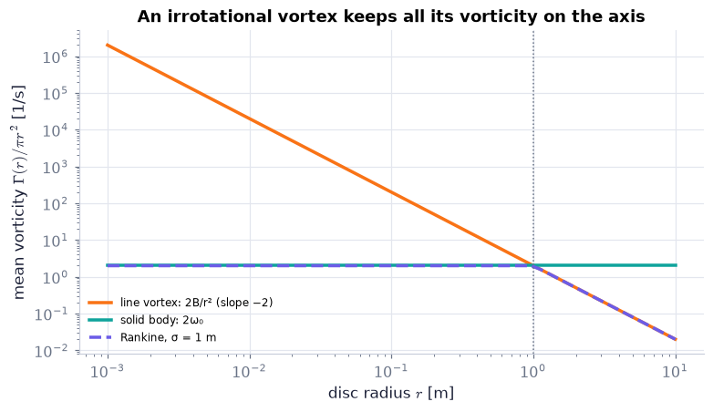

```python
rr = np.geomspace(1e-3, 10, 60)                        # disc radii from 1 mm to 10 m
kw = dict(Gamma=2*np.pi, sigma=1.0)
fig, ax = plt.subplots(figsize=(7, 4))                  # log–log axes (Ch. 1 P13)
ax.loglog(rr, ch03.mean_vorticity_in_disc("line", rr, **kw), color=COLORS["orange"], lw=2.3, label="line vortex: 2B/r² (slope −2)")
ax.loglog(rr, ch03.mean_vorticity_in_disc("solid", rr, **kw), color=COLORS["teal"], lw=2.3, label="solid body: 2ω₀")   # flat
ax.loglog(rr, ch03.mean_vorticity_in_disc("rankine", rr, **kw), "--", color=COLORS["accent"], lw=2.3, label="Rankine, σ = 1 m")
ax.axvline(1.0, color=COLORS["muted"], ls=":", lw=1)    # the core radius σ
ax.set_xlabel("disc radius $r$ [m]"); ax.set_ylabel(r"mean vorticity $\Gamma(r)/\pi r^2$ [1/s]"); ax.legend(fontsize=8)
ax.set_title("An irrotational vortex keeps all its vorticity on the axis")
savefig(fig, "ch03", "mean_vorticity_disc"); plt.show() # save to outputs/ch03 and draw
```

**What you see.** A straight orange line of slope −2, a flat teal line, and a dashed purple curve that switches from one to the other at r = σ = 1 m.

**How to read it.** The mean vorticity in a disc is its circulation divided by its area. For the line vortex the circulation is the same for every disc, so the smaller the disc, the larger the average — all of it sits on the axis. A real vortex has a finite core, inside which it behaves like a solid body.

**What would change if…** …σ shrank toward zero: the purple curve's flat part would climb (Γ/πσ²) and the Rankine vortex would approach the line vortex.

```python
nfr = 60 if not FAST else 30                           # frames
times = np.linspace(0, 2*np.pi, nfr)                   # one revolution of the solid body [s]
radii = np.array([0.5, 1.0, 1.5, 2.0])                 # four paddle wheels [m]
cases = {"solid body, ω₀ = 1 1/s": (lambda r: 1.0*np.ones_like(r), 2.0),      # (orbit rate u_θ/r [rad/s], ω_z [1/s])
         "line vortex, B = 1 m²/s": (lambda r: 1.0/r**2, 0.0)}
fig, axs = plt.subplots(1, 2, figsize=(9.6, 4.6))       # solid body left, line vortex right
arts = []                                              # the artists each frame updates
for ax, (name, (Om, wz)) in zip(axs, cases.items()):
    ax.set_aspect("equal"); ax.set_xlim(-2.5, 2.5); ax.set_ylim(-2.5, 2.5); ax.set_title(name)   # fixed limits
    for R_ in radii: ax.add_patch(plt.Circle((0, 0), R_, fill=False, color=COLORS["grid"]))    # the streamlines (circles)
    (wheels,) = ax.plot([], [], color=COLORS["ink"], lw=1.6)   # all four paddle wheels in one line
    (el,) = ax.plot([], [], color=COLORS["teal"], lw=2)        # the polar element's outline
    arts.append((Om, wz, wheels, el))
axs[0].set_xlabel("$x$ [m]"); axs[1].set_xlabel("$x$ [m]"); axs[0].set_ylabel("$y$ [m]")
sq = np.linspace(0, 1, 15)                             # points along each edge of the element

def update(i):                                         # draw frame i
    t = times[i]                                       # time of this frame [s]
    out = []                                           # artists that changed
    for Om, wz, wheels, el in arts:                    # both vortices
        ang = Om(radii)*t                              # each wheel's position angle: it orbits at u_θ/r
        spin = 0.5*wz*t                                # each wheel turns at ½ω_z (D12, D17)
        xs, ys = [], []                                # blade end points, NaN-separated
        for R_, a in zip(radii, ang):                  # one wheel per radius
            cx, cy = R_*np.cos(a), R_*np.sin(a)        # its hub
            for b in (spin, spin + np.pi/2):           # two crossing blades
                xs += [cx - 0.22*np.cos(b), cx + 0.22*np.cos(b), np.nan]; ys += [cy - 0.22*np.sin(b), cy + 0.22*np.sin(b), np.nan]
        wheels.set_data(xs, ys)                        # move the wheels
        rr_ = np.r_[1 + 0.4*sq, np.full(15, 1.4), 1.4 - 0.4*sq, np.full(15, 1.0)]   # element outline: r from 1 to 1.4 m
        tt_ = np.r_[np.zeros(15), 0.35*sq, np.full(15, 0.35), 0.35 - 0.35*sq]      # … and θ from 0 to 0.35 rad
        th_now = tt_ + Om(rr_)*t                       # every boundary point orbits at its own rate
        el.set_data(rr_*np.cos(th_now), rr_*np.sin(th_now))   # back to x, y
        out += [wheels, el]
    return out

show_animation(animate(update, frames=nfr, fig=fig, interval=70), player="video")   # smooth MP4
```

[video not shown]

**What does the code above do?**

1. Every point moves on its circle at the orbit rate $u_\theta/r$ (1 rad/s for the solid body, $1/r^2$ for the line vortex).
2. Each paddle wheel is turned by $\tfrac12\omega_z t$ — the element spin of D12, with $\omega_z$ from (3.23).
3. The teal polar element is drawn by carrying 60 points of its outline.

**What you see.** Left: four wheels going round together, each turning once per revolution, and a teal element that keeps its shape. Right: wheels orbiting at very different speeds but never turning, and an element sheared into a thin wedge.

**How to read it.** On the left, going round and spinning go together (ω_z = 2ω₀). On the right the wheels keep pointing the same way while they circle — ω_z = 0 — although the fluid clearly deforms: fast inside, slow outside.

**What would change if…** …a wheel were added at r = 0.2 m on the right: it would race round (25 rad/s) — and still not turn.

**What would change if…** …a real drain vortex were measured? Near the axis the speed does not blow up like 1/r; the core turns like a solid body and the outside like a line vortex — the Rankine and Gaussian models of C14.

### 🧩 Real vortices have a core: the Rankine and Gaussian models (3.28)–(3.29) `C14`

*The question:* A tornado's wind is calm at its centre, fastest a little way out and weaker far away. Which simple formula reproduces that profile, and where exactly is the fastest wind?

*In one line:* $u_\theta=\frac{\Gamma r}{2\pi\sigma^2}\ (r\le\sigma),\ \frac{\Gamma}{2\pi r}\ (r>\sigma)$ *(3.28)* · $u_\theta=\frac{\Gamma}{2\pi r}\big(1-e^{-r^2/\sigma^2}\big)$ *(3.29)*

#### The problem in plain words

Tornado chasers, hurricane forecasters and aircraft-wake engineers all quote two numbers: the peak wind and the radius where it occurs. Pure solid-body rotation grows for ever; the line vortex blows up at the axis. Joining them gives a vortex with a spinning core and an irrotational skirt — the model behind every cyclone schematic.

#### The idea

```
              core (r < σ): solid body, ω_z = Γ/πσ²       outside: irrotational, u_θ = Γ/2πr
Rankine:   sharp join at r = σ (speed continuous, vorticity jumps)     → peak at r = σ exactly
Gaussian:  smooth join, ω_z = (Γ/πσ²) e^{−r²/σ²}                        → peak at r ≈ 1.1209 σ
```

📝 **Note.** **Real vortices** `N42` — bathtub drains, wing-tip vortices (Ch. 14), tornadoes, tropical cyclones (Ch. 13) — combine a nearly solid-body core with a nearly irrotational outer flow and have bounded speeds.

#### The maths — the Rankine vortex

Uniform vorticity inside a core of radius σ, none outside; Γ is the total circulation:

$$\omega_z(r)=\begin{Bmatrix}\Gamma/\pi\sigma^2=\text{const.}&r\le\sigma\\0&r>\sigma\end{Bmatrix}\quad\text{and}\quad u_\theta(r)=\begin{Bmatrix}(\Gamma/2\pi\sigma^2)r&r\le\sigma\\\Gamma/2\pi r&r>\sigma\end{Bmatrix}\qquad(3.28)$$

A piecewise formula is evaluated with `np.where(r <= sigma, inside, outside)` (Ch. 1 P46).

#### 🧮 Derivation — The Rankine vortex is self-consistent: core vorticity, continuity at σ, peak at σ `D18` (Eq. 3.28)

**What we want to show.** Check that the two halves of (3.28), $u_\theta=\frac{\Gamma r}{2\pi\sigma^2}\ (r\le\sigma),\ \frac{\Gamma}{2\pi r}\ (r>\sigma)$ fit together — uniform vorticity inside, none outside, speed continuous, total circulation Γ — and find the peak speed; the book states all of this without working.

**Assumptions.** Axisymmetric (u_r = 0, no θ-dependence).

**The plan.**

1. Vorticity in each region by (3.23), $\omega_z=\frac1r\frac{\partial}{\partial r}(ru_\theta)-\frac1r\frac{\partial u_r}{\partial\theta}$.
2. Continuity of the speed at σ.
3. Total circulation.
4. Where the speed peaks.

**Tools we use** (each explained before this point): (3.23), $\omega_z=\frac1r\frac{\partial}{\partial r}(ru_\theta)-\frac1r\frac{\partial u_r}{\partial\theta}$ (D17) · derivative of a product · the circulation of a centred circle, (3.24), $\Gamma=2\pi ru_\theta=2\pi r^2\omega_0$ (solid body) and (3.26), $\Gamma=2\pi ru_\theta=2\pi B$ (line vortex) (N37, N39) · continuity at a join and a kink as a maximum (gloss).

**We start from**

$$ \text{(3.28):}\ u_\theta(r)=\frac{\Gamma}{2\pi\sigma^2}r\ \text{for}\ r\le\sigma\ \text{,}\ u_\theta(r)=\frac{\Gamma}{2\pi r}\ \text{for}\ r>\sigma\ \text{,}\ u_r=0 $$

*In words:* solid-body rotation inside a core of radius σ, a line vortex outside.

**Step 1 of 5 — Vorticity inside by (3.23).**

$$ \omega_z=\dfrac1r\dfrac{d}{dr}\Big(\dfrac{\Gamma r^2}{2\pi\sigma^2}\Big)=\dfrac{\Gamma}{\pi\sigma^2} $$

- *Why we can do this:* u_r = 0 leaves the first term of (3.23), $\omega_z=\frac1r\frac{\partial}{\partial r}(ru_\theta)-\frac1r\frac{\partial u_r}{\partial\theta}$; $d(r^2)/dr=2r$ and the r cancels.
- *In words:* The core has uniform vorticity — a solid-body rotation with $\omega_0=\Gamma/2\pi\sigma^2$.

**Step 2 of 5 — Vorticity outside by (3.23).**

$$ \omega_z=\dfrac1r\dfrac{d}{dr}\Big(\dfrac{\Gamma}{2\pi}\Big)=0 $$

- *Why we can do this:* Outside, r u_θ = Γ/2π is constant, so its derivative is zero.
- *In words:* No vorticity outside the core.

**Step 3 of 5 — Compare the two speeds at σ.**

$$ \dfrac{\Gamma}{2\pi\sigma^2}\sigma=\dfrac{\Gamma}{2\pi\sigma} $$

- *Why we can do this:* Evaluate each branch at r = σ (gloss: a join is continuous when the two sides agree there). The speed is continuous; the vorticity jumps from Γ/πσ² to 0.
- *In words:* No jump in speed, a jump in spin.

**Step 4 of 5 — Total circulation.**

$$ \Gamma(r\ge\sigma)=2\pi r\,u_\theta=\Gamma=\dfrac{\Gamma}{\pi\sigma^2}\cdot\pi\sigma^2 $$

- *Why we can do this:* The centred-circle circulation, (3.24), $\Gamma=2\pi ru_\theta=2\pi r^2\omega_0$ (solid body) and (3.26), $\Gamma=2\pi ru_\theta=2\pi B$ (line vortex): outside the core $ru_\theta=\Gamma/2\pi$, so the circle gives Γ; by Stokes it equals core vorticity × core area.
- *In words:* All the circulation lives in the core.

**Step 5 of 5 — Locate the peak speed.**

$$ u_{\max}=\dfrac{\Gamma}{2\pi\sigma}\ \text{at}\ r=\sigma $$

- *Why we can do this:* $du_\theta/dr>0$ inside (linear rise) and $<0$ outside (1/r fall): the derivative changes sign at σ — a maximum at a kink, not at a zero of the derivative (gloss).
- *In words:* The fastest wind is at the edge of the core.

**Result**

$$ \omega_z=\Gamma/\pi\sigma^2\ \text{(}\ r\le\sigma\ \text{), 0 (}\ r>\sigma\ \text{); u\_θ continuous at σ with}\ u_{\max}=\Gamma/2\pi\sigma $$

*In words:* a spinning core wrapped in an irrotational skirt, fastest at the core's edge.

**What it means.** The simplest model of a real vortex: bounded speed, finite core. The jump in vorticity is unphysical for a viscous fluid (viscosity smooths it — the Gaussian of D19).

**Check it.** Units: Γ/πσ² [1/s], Γ/2πσ [m/s] ✓. σ → 0 at fixed Γ: the core shrinks to the line vortex ✓. Numbers (Γ = 2π m²/s, σ = 1 m): inside u = r, ω = 2 s⁻¹; peak 1 m/s at 1 m ✓.

> ⚠️ **Common confusion (traps in `D18`):** Setting du_θ/dr = 0 to find the maximum (there is no such point — the maximum is a kink). Thinking the vorticity is continuous because the speed is.

> 📎 **Primer — substitution in an integral.** `P106` · Replace a messy variable by a simpler one and convert dx too: with $s=r^2/\sigma^2$, $ds=2r\,dr/\sigma^2$, so $2\pi r\,dr=\pi\sigma^2\,ds$ and the limits r = 0 … R become s = 0 … R²/σ². The value of the integral does not change.

```python
from scipy.integrate import quad                     # adaptive quadrature (P87)
sig, R = 1.0, 1.5                                    # core radius and outer radius [m]
lhs = quad(lambda r: np.exp(-r**2/sig**2)*2*np.pi*r, 0, R)[0]      # in r
rhs = quad(lambda s: np.exp(-s)*np.pi*sig**2, 0, R**2/sig**2)[0]   # in s = r²/σ²
print(round(lhs, 4), round(rhs, 4))                  # 2.8105 2.8105 (= π(1 − e^−2.25))
```

```
2.8105 2.8105
```

#### 🧮 Derivation — The Gaussian vortex's speed from its vorticity, Eq. (3.29) `D19` (Eq. 3.29)

**What we want to show.** Show that the speed profile of the Gaussian vortex (3.29), $u_\theta=\frac{\Gamma}{2\pi r}\big(1-e^{-r^2/\sigma^2}\big)$ follows from its vorticity by Stokes' theorem — the book states both halves without connecting them — and find its two limits.

**Assumptions.** Axisymmetric flow, u_r = 0 (step 4: u_θ is the same all round the circle).

**The plan.**

1. Circulation inside radius r as an area integral of vorticity.
2. Substitute to do the integral.
3. Circulation as u_θ times the circle's length.
4. Solve for u_θ.
5. Limits near and far.

**Tools we use** (each explained before this point): Stokes/circulation (3.18), $\Gamma=\oint_C\mathbf u\cdot d\mathbf s=\int_A\boldsymbol\omega\cdot\mathbf n\,dA$ (R07) · substitution in an integral (primer in C14) · ∫e^{−s}ds (ch01 P36) · the circle integral $\Gamma=2\pi ru_\theta$ of (3.24), $\Gamma=2\pi ru_\theta=2\pi r^2\omega_0$ (N37) · first-order Taylor of e^{−x} (ch01 P26).

**We start from**

$$ \omega_z(r)=\frac{\Gamma}{\pi\sigma^2}\exp(-r^2/\sigma^2) $$

*In words:* the vorticity is largest on the axis and falls off smoothly over a core radius σ.

**Step 1 of 7 — Circulation inside radius r.**

$$ \Gamma(r)=\displaystyle\int_0^r\omega_z(r')\,2\pi r'\,dr' $$

- *Why we can do this:* (3.18), $\Gamma=\oint_C\mathbf u\cdot d\mathbf s=\int_A\boldsymbol\omega\cdot\mathbf n\,dA$: circulation round the circle = vorticity flux through the disc; for axisymmetric ω split the disc into rings of area 2πr′dr′.
- *In words:* Add up the vorticity inside the circle.

**Step 2 of 7 — Substitute s = r′²/σ².**

$$ \Gamma(r)=\dfrac{\Gamma}{\pi\sigma^2}\,\pi\sigma^2\displaystyle\int_0^{r^2/\sigma^2}e^{-s}\,ds $$

- *Why we can do this:* With $ds=2r'dr'/\sigma^2$, $2\pi r'dr'=\pi\sigma^2ds$ and the limits become 0 … r²/σ² (substitution primer).
- *In words:* A plain exponential integral.

**Step 3 of 7 — Integrate the exponential.**

$$ \Gamma(r)=\Gamma\big(1-e^{-r^2/\sigma^2}\big) $$

- *Why we can do this:* $\int_0^Xe^{-s}ds=1-e^{-X}$ (P36); the π σ² cancel.
- *In words:* The fraction of the total circulation inside r.

**Step 4 of 7 — Circulation of the circle directly.**

$$ \Gamma(r)=\oint\mathbf u\cdot d\mathbf s=2\pi r\,u_\theta(r) $$

- *Why we can do this:* On a centred circle $d\mathbf s=r\,d\theta\,\mathbf e_\theta$ and u_θ is constant round it (axisymmetric) — as in (3.24), $\Gamma=\int_0^{2\pi}u_\theta r\,d\theta=2\pi ru_\theta$.
- *In words:* The same circulation measured on the loop itself.

**Step 5 of 7 — Equate and solve for u_θ.**

$$ u_\theta(r)=\dfrac{\Gamma}{2\pi r}\Big(1-e^{-r^2/\sigma^2}\Big) $$

- *Why we can do this:* Steps 3 and 4 describe the same number; divide by 2πr (r > 0). This is (3.29), $u_\theta=\frac{\Gamma}{2\pi r}\big(1-e^{-r^2/\sigma^2}\big)$.
- *In words:* The speed profile of the Gaussian vortex.

**Step 6 of 7 — Near the axis, r ≪ σ.**

$$ u_\theta\approx\dfrac{\Gamma}{2\pi\sigma^2}\,r $$

- *Why we can do this:* First-order Taylor $e^{-x}\approx1-x$ for small $x=r^2/\sigma^2$, so $1-e^{-x}\approx r^2/\sigma^2$.
- *In words:* A solid-body core with $\omega_0=\Gamma/2\pi\sigma^2$ — like the Rankine core.

**Step 7 of 7 — Far away, r ≫ σ.**

$$ u_\theta\to\dfrac{\Gamma}{2\pi r} $$

- *Why we can do this:* $e^{-r^2/\sigma^2}\to0$ much faster than any power of r.
- *In words:* A line vortex with B = Γ/2π — irrotational outside the core.

**Result**

$$ u_\theta(r)=\frac{\Gamma}{2\pi r}\big(1-\exp(-r^2/\sigma^2)\big)\ \text{(3.29), with}\ \Gamma(r)=\Gamma(1-e^{-r^2/\sigma^2}) $$

*In words:* the speed is the circulation enclosed divided by the circle's length.

**What it means.** Any axisymmetric vorticity profile gives its speed the same way: $u_\theta=\Gamma(r)/2\pi r$. The Gaussian is the Lamb–Oseen vortex of viscous flow at one instant (σ² = 4νt, Ch. 5/8). Near r = 0 the formula subtracts nearly equal numbers — compute it with `-np.expm1(-x)` (primer).

**Check it.** Units m/s ✓. Γ(∞) = Γ ✓. Numbers (Γ = 2π, σ = 1): u_θ(1) = 0.632 m/s; u_θ(5) = (1 − e^{−25})/5 = 0.2 to 11 digits ✓. (3.23), $\omega_z=\frac1r\frac{\partial}{\partial r}(ru_\theta)-\frac1r\frac{\partial u_r}{\partial\theta}$ applied to (3.29), $u_\theta=\frac{\Gamma}{2\pi r}\big(1-e^{-r^2/\sigma^2}\big)$ gives back ω_z (the sympy cell below) ✓.

```python
r, sig, Gam = sp.symbols('r sigma Gamma', positive=True)            # radius, core radius, circulation
uth = Gam/(2*sp.pi*r)*(1 - sp.exp(-r**2/sig**2))                   # the Gaussian speed profile (3.29)
wz = sp.diff(r*uth, r)/r                                            # (3.23) with u_r = 0: (1/r) d(r u_θ)/dr
print(sp.simplify(wz - Gam/(sp.pi*sig**2)*sp.exp(-r**2/sig**2)))    # 0: it gives back ω_z of (3.29)
print(sp.limit(2*sp.pi*r*uth, r, sp.oo))                            # Γ: all the circulation, far away (step 3)
```

```
0
Gamma
```

> ⚠️ **Common confusion (traps in `D19`):** Forgetting the ring weight 2πr′ in step 1. Thinking the core has zero vorticity because the speed vanishes at the axis (the vorticity is largest there). Evaluating 1 − exp(−x) naively for tiny x.

📝 **Note.** **The Gaussian vortex** `N43` — the smooth version. It is the Lamb–Oseen vortex of viscous flow at one instant, with $\sigma^2=4\nu t$ growing in time (Ch. 5, Ch. 8) — our pointer, not the book's.

$$ \omega_z(r)=\frac{\Gamma}{\pi\sigma^2}\exp\!\big(-r^2/\sigma^2\big)\quad\text{and}\quad u_\theta(r)=\frac{\Gamma}{2\pi r}\Big(1-\exp\!\big(-r^2/\sigma^2\big)\Big) \qquad \text{(3.29)} $$

> 📎 **Primer — np.expm1 and cancellation near zero.** `P107` · Near r = 0, $1-e^{-x}$ subtracts two numbers that are almost equal and loses digits (*catastrophic cancellation*). `np.expm1(y)` computes $e^y-1$ accurately for tiny y, so $1-e^{-x}=$ `-np.expm1(-x)`. `gaussian_vortex` uses it and returns exactly 0 at r = 0.

```python
x = 1e-12                                            # a tiny argument
print(1 - np.exp(-x), -np.expm1(-x))                 # 9.99977878e-13 (wrong from the 5th digit on) vs 9.999999999995e-13
```

```
9.999778782798785e-13 9.999999999995e-13
```

> 📎 **Primer — scipy.optimize.brentq.** `P108` · Finds a root of f(x) = 0 inside a bracket [a, b] where f changes sign; guaranteed to converge, and fast. Choose the bracket so it excludes roots you do not want.

```python
from scipy.optimize import brentq                    # bracketing root finder
g = lambda x: 1 + 2*x - np.exp(x)                    # the equation of D20
print(round(g(0.5), 4), round(g(3.0), 4))            # 0.3513 > 0, −13.0855 < 0: a sign change in (0.5, 3)
print(brentq(g, 0.5, 3.0))                           # 1.2564312086…
```

```
0.3513 -13.0855
1.256431208626068
```

#### 🧮 Derivation — Where the Gaussian vortex's speed peaks: 1 + 2r²/σ² = e^{r²/σ²}, r ≈ 1.1209σ `D20`

**What we want to show.** Find the radius of maximum speed of the Gaussian vortex — the book quotes r ≈ 1.12091σ and leaves the work to Exercise 3.26.

**Assumptions.** Γ, σ > 0 (steps 1, 3).

**The plan.**

1. Write u_θ with one dimensionless variable.
2. Differentiate and set to zero.
3. Simplify to the book's equation.
4. Solve numerically, excluding the trivial root.

**Tools we use** (each explained before this point): Product rule (ch01 P38) and chain rule · maximum of a function (gloss) · scipy.optimize.brentq (primer in C14) · Lambert W (gloss in the check).

**We start from**

$$ \text{(3.29):}\ u_\theta(r)=\frac{\Gamma}{2\pi r}\big(1-e^{-r^2/\sigma^2}\big) $$

*In words:* zero on the axis and far away, so a maximum lies between.

**Step 1 of 7 — Write u_θ with x = r²/σ².**

$$ u_\theta=\dfrac{\Gamma}{2\pi\sigma}\,f(x),\qquad f(x)=\dfrac{1-e^{-x}}{\sqrt x} $$

- *Why we can do this:* Substitute r = σ√x; the constant Γ/2πσ does not affect where the maximum is, and r ↦ x is increasing for r > 0.
- *In words:* One curve f(x) for every vortex; σ only rescales it.

**Step 2 of 7 — Differentiate f.**

$$ f'(x)=\dfrac{e^{-x}}{\sqrt x}-\dfrac{1-e^{-x}}{2x^{3/2}} $$

- *Why we can do this:* Product rule (P38) on $(1-e^{-x})\,x^{-1/2}$: $(e^{-x})x^{-1/2}+(1-e^{-x})(-\tfrac12x^{-3/2})$; the peak is where this slope vanishes.
- *In words:* The slope of the speed curve.

**Step 3 of 7 — Set f′ = 0, multiply by 2x^{3/2}.**

$$ 2x\,e^{-x}-(1-e^{-x})=0 $$

- *Why we can do this:* A smooth maximum has zero slope (gloss); x > 0, so multiplying by $2x^{3/2}$ keeps the roots.
- *In words:* The condition for the peak.

**Step 4 of 7 — Multiply by e^{x}.**

$$ 1+2x=e^{x} $$

- *Why we can do this:* $e^x\neq0$; rearrange $2x-e^x+1=0$. With x = r²/σ² this is the book's $1+2r^2/\sigma^2=\exp(r^2/\sigma^2)$.
- *In words:* A straight line meets an exponential.

**Step 5 of 7 — Exclude the trivial root.**

$$ x=0\ \text{solves it but is the axis} $$

- *Why we can do this:* 1 + 0 = e⁰, but r = 0 is where u_θ = 0 — a minimum. The line and the exponential cross once more for x > 0 (the exponential starts slower, then overtakes).
- *In words:* We want the second crossing.

**Step 6 of 7 — Solve numerically in a bracket.**

$$ x^*=1.25643\ \ (\text{brentq on }(0.5,3)) $$

- *Why we can do this:* The equation has no elementary solution; $g(x)=1+2x-e^x$ is +0.351 at 0.5 and −13.1 at 3, so brentq (primer) finds the one root between.
- *In words:* The peak is at x ≈ 1.2564.

**Step 7 of 7 — Return to r and the peak speed.**

$$ r^*=\sigma\sqrt{x^*}=1.12091\,\sigma,\qquad u_{\max}=0.6382\,\dfrac{\Gamma}{2\pi\sigma} $$

- *Why we can do this:* Undo x = r²/σ²; evaluate f(x*) = (1 − e^{−1.2564})/1.1209 = 0.6382.
- *In words:* The strongest wind is about 12 % outside σ, 36 % weaker than the Rankine peak.

**Result**

$$ 1+2\frac{r^2}{\sigma^2}=\exp\!\big(r^2/\sigma^2\big)\ \text{,}\ r^*\approx1.12091\,\sigma\ \text{,}\ u_{\max}\approx0.6382\,\Gamma/(2\pi\sigma) $$

*In words:* the Gaussian vortex's peak sits just outside its core radius.

**What it means.** Measuring the radius of maximum wind of a vortex that looks Gaussian gives its core size σ = r*/1.121 — how tornado and wake-vortex radars are read. For the Rankine model the same radius is σ itself.

**Check it.** Units: x dimensionless ✓. Residual $1+2x^*-e^{x^*}$ < 1e-14 ✓. Lambert W cross-check (gloss: W is the inverse of $we^w$): $x^*=-W_{-1}(-e^{-1/2}/2)-\tfrac12=1.2564312086$ ✓ (`scipy.special.lambertw(z, -1)`). Numbers (Γ = 2π, σ = 1): u_max = 0.638 m/s at 1.121 m ✓.

> ⚠️ **Common confusion (traps in `D20`):** Accepting x = 0. Differentiating with respect to r in one term and x in another. Taking r* = 1.2564σ (that is x*, not √x*).

📝 **Note.** **Where the wind peaks** `N44` — Rankine: at r = σ exactly, $u_{\max}=\Gamma/2\pi\sigma$. Gaussian: where the equation below holds, i.e. $r\approx1.1209\,\sigma$, with $u_{\max}\approx0.6382\,\Gamma/(2\pi\sigma)$ — 36 % below the Rankine peak for the same Γ and σ.

$$ 1+2\,\frac{r^2}{\sigma^2}=\exp\!\big(r^2/\sigma^2\big) $$

#### ✏️ Tiny example: Γ = 2π m²/s, σ = 1 m

1. Rankine inside: $u_\theta=(2\pi/2\pi\cdot1)r=r$ m/s; $\omega_z=2\pi/\pi=2$ s⁻¹.
2. Rankine peak at r = 1 m: 1 m/s; at r = 2 m: $2\pi/(2\pi\cdot2)=0.5$ m/s.
3. Gaussian at r = 1 m: $u_\theta=(1/1)(1-e^{-1})=0.632$ m/s.
4. Gaussian peak: r = 1.1209 m, $x=r^2=1.2564$, $u_\theta=(1-e^{-1.2564})/1.1209=0.7153/1.1209=0.638$ m/s.
5. Far away both → 1/r: at 5 m, 0.200 m/s (Gaussian $(1-e^{-25})/5=0.2$ to 11 digits).

```python
Gam, sig = 2*np.pi, 1.0                                      # circulation [m²/s] and core radius [m]
r = np.array([0.5, 1.0, 1.1209, 2.0, 5.0])                   # five radii [m]
print("Rankine  u, w:", [np.round(v, 4) for v in ch03.rankine_vortex(r, Gam, sig)])    # (3.28): u_θ [m/s], ω_z [1/s]
print("Gaussian u, w:", [np.round(v, 4) for v in ch03.gaussian_vortex(r, Gam, sig)])   # (3.29)
rstar = ch03.gaussian_vortex_max_radius(sig)                 # the root of 1 + 2x = e^x by brentq (D20)
print(rstar, ch03.gaussian_vortex(rstar, Gam, sig)[0])       # 1.1209064 m and the peak speed 0.63817 m/s
print(ch03.gaussian_vortex_max_radius(sig, method="lambertw"))   # the same radius from the Lambert-W formula
print(ch03.circulation_circle("gaussian", 3.0, Gamma=Gam, sigma=sig)/Gam)   # Γ(3σ)/Γ = 1 − e^−9
for name, s_, umax in (("bathtub", 5e-3, 0.3), ("tornado", 100.0, 60.0), ("tropical cyclone", 36e3, 50.0)):
    G_ = 2*np.pi*s_*umax/0.6382                              # Γ from the peak wind of a Gaussian vortex [m²/s]
    print(f"{name:17s} sigma = {s_:8.3g} m  u_max = {umax:4.1f} m/s  ->  Gamma = {G_:.2g} m^2/s, r_max = {1.1209*s_:.3g} m")
```

```
Rankine  u, w: [array([0.5   , 1.    , 0.8921, 0.5   , 0.2   ]), array([2., 2., 0., 0., 0.])]
Gaussian u, w: [array([0.4424, 0.6321, 0.6382, 0.4908, 0.2   ]), array([1.5576, 0.7358, 0.5693, 0.0366, 0.    ])]
1.120906422778534 0.6381726863389515
1.120906422778534
0.9998765901959134
bathtub           sigma =    0.005 m  u_max =  0.3 m/s  ->  Gamma = 0.015 m^2/s, r_max = 0.0056 m
tornado           sigma =      100 m  u_max = 60.0 m/s  ->  Gamma = 5.9e+04 m^2/s, r_max = 112 m
tropical cyclone  sigma =  3.6e+04 m  u_max = 50.0 m/s  ->  Gamma = 1.8e+07 m^2/s, r_max = 4.04e+04 m
```

**What does the code above do?**

1. Both models at five radii: Rankine (0.5, 1, 0.892, 0.5, 0.2) m/s with a vorticity step 2 → 0; Gaussian (0.442, 0.632, 0.638, 0.491, 0.200) m/s with a smooth bell.
2. The maximum by `brentq` (D20) and its Lambert-W twin: 1.1209064 m.
3. $\Gamma(r)/\Gamma\to1$ outside the core (D19 step 3): 0.99988 at 3σ.
4. Our order-of-magnitude real vortices span nine orders of magnitude in Γ with the same shape.

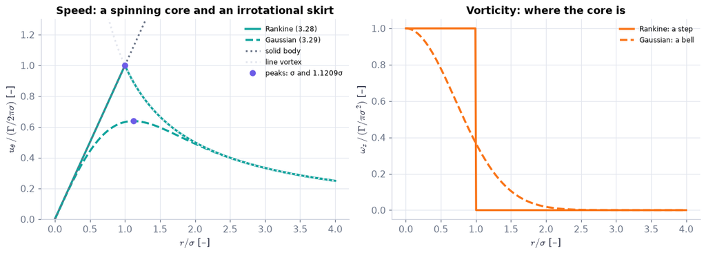

```python
x = np.linspace(1e-3, 4, 400)                                # r/σ [–]
uR, wR = ch03.rankine_vortex(x, 2*np.pi, 1.0)                # Γ = 2π, σ = 1: u is already in units of Γ/2πσ = 1 m/s; ω/2 in units of Γ/πσ² = 2 1/s
uG, wG = ch03.gaussian_vortex(x, 2*np.pi, 1.0)
fig, (a, b) = plt.subplots(1, 2, figsize=(11, 3.9))           # (a) speed, (b) vorticity
a.plot(x, uR, color=COLORS["teal"], lw=2.3, label="Rankine (3.28)")          # kink at r = σ
a.plot(x, uG, "--", color=COLORS["teal"], lw=2.3, label="Gaussian (3.29)")   # smooth
a.plot(x, x, ":", color=COLORS["muted"], label="solid body"); a.plot(x, 1/x, ":", color=COLORS["grid"], label="line vortex")   # ghosts
a.plot([1.0], [1.0], "o", color=COLORS["accent"]); a.plot([1.1209], [0.6382], "o", color=COLORS["accent"], label="peaks: σ and 1.1209σ")
a.set_ylim(0, 1.3); a.set_xlabel(r"$r/\sigma$ [–]"); a.set_ylabel(r"$u_\theta\,/\,(\Gamma/2\pi\sigma)$ [–]"); a.legend(fontsize=8)
a.set_title("Speed: a spinning core and an irrotational skirt")
b.plot(x, wR/2, color=COLORS["orange"], lw=2.3, label="Rankine: a step")     # uniform core, nothing outside
b.plot(x, wG/2, "--", color=COLORS["orange"], lw=2.3, label="Gaussian: a bell")   # e^{−r²/σ²}
b.set_xlabel(r"$r/\sigma$ [–]"); b.set_ylabel(r"$\omega_z\,/\,(\Gamma/\pi\sigma^2)$ [–]"); b.legend(fontsize=8)   # dimensionless
b.set_title("Vorticity: where the core is")
savefig(fig, "ch03", "vortex_profiles"); plt.show()           # save to outputs/ch03 and draw
```

**What you see.** Two humps with peaks at 1 and ≈ 1.12 (left); a step and a bell (right).

**How to read it.** The core is where the vorticity is; outside it both speed profiles follow the line vortex $\Gamma/2\pi r$. The smooth Gaussian vorticity moves the peak outward and lowers it (0.638 instead of 1 in units of Γ/2πσ).

**What would change if…** …σ were doubled at the same Γ: in physical units the peak would halve and move twice as far out ($u_{\max}\propto\Gamma/\sigma$).

```python
rr = np.linspace(0.005, 5, 300)                              # radius [m]

def profiles(s):                                             # Γ = 2π m²/s, core radius s [m]
    rs = ch03.gaussian_vortex_max_radius(s)                  # Gaussian peak radius (D20)
    return {"Rankine u_θ": (rr, ch03.rankine_vortex(rr, 2*np.pi, s)[0]),        # (3.28)
            "Gaussian u_θ": (rr, ch03.gaussian_vortex(rr, 2*np.pi, s)[0]),      # (3.29)
            "peaks (σ and 1.1209σ)": ([s, rs], [1.0/s, ch03.gaussian_vortex(rs, 2*np.pi, s)[0]])}   # Rankine peak Γ/2πσ = 1/s

fig = slider_figure(profiles, "σ", np.linspace(0.25, 2, 15 if not FAST else 8), unit="m", xlabel="r [m]",
                    ylabel="u_θ [m/s]", xrange=[0, 5], yrange=[0, 4.2], modes={"peaks (σ and 1.1209σ)": "markers"},
                    title="A smaller core spins faster: u_max ∝ Γ/σ")    # fixed axes
recolor(fig, {"Rankine u_θ": COLORS["teal"], "Gaussian u_θ": COLORS["teal"], "peaks (σ and 1.1209σ)": COLORS["accent"]},
        dashes={"Gaussian u_θ": "dash"})                     # Gaussian dashed, as in the static figure
fig.show()                                                   # draw it
```

[interactive chart not shown]

**What does the code above do?**

The slider changes the core radius σ at fixed Γ = 2π m²/s; the markers sit at the two peaks.

**What you see.** A teal kinked curve (Rankine), a dashed smooth one (Gaussian) and two purple markers.

**How to read it.** The Rankine peak sits on the kink at σ, the Gaussian peak at 1.12σ, both moving outward and down as σ grows; beyond about 2σ the two curves coincide with Γ/2πr.

**What would change if…** …Γ doubled: every curve would double in height; the peak radii would not move.

#### 🎮 Interactive: Going round in circles ≠ spinning

**Why interactive:** "going round" and "spinning" can only be told apart in motion; watching wheels orbit and turn (or not) on one clock, and dragging a loop on and off the axis, makes the difference visible. Four vortices on one stage: paddle wheels ride with the flow and turn at half the local vorticity, a loop you can drag measures the circulation, and the profiles $u_\theta(r)$ and $\omega_z(r)$ show where the core is. The same clock runs the tracers, the wheels and the circulation graph.

**What to try:**

- Mode 'line vortex': the wheels orbit but always point the same way; drag the loop off the axis — Γ drops to 0.
- Mode 'solid body': every wheel turns once per revolution.
- Mode 'Gaussian': drag σ and watch the peak marker sit at 1.1209σ.
- Preset 'tropical cyclone': read the radius of maximum wind and the core vorticity in Explain.

```python
show_viz("ch03", "vortex_paddle_wheels")   # full-width explainer; ⤢ Full screen for more room
```

🎮 Interactive 6/7 Going round in circles or spinning? Open alone ↗

[interactive chart not shown]

**What would change if…** …the fluid were viscous? The Gaussian core would spread as $\sigma^2=4\nu t$ while Γ stays fixed (Ch. 5). And all of this has been about *points* — §3.6 asks how a quantity inside a whole moving volume changes.

## 3.6 Reynolds Transport Theorem

**What is this section about?** How fast does the amount of something inside a volume change when the volume itself moves and deforms? In one dimension this is Leibniz's rule; in three it is the Reynolds transport theorem — the bridge from "what happens to a moving lump of fluid" to equations at fixed points, used for every conservation law in Ch. 4.

### 🧩 The Reynolds transport theorem: change inside a moving volume (3.35) `C15`

*The question:* A balloon is being inflated in a room that is warming up. How fast does the heat content inside the balloon change — and which part of that comes from the warming, which from the balloon's growing skin?

*In one line:* $\frac{d}{dt}\int_{V^*}F\,dV=\int_{V^*}\frac{\partial F}{\partial t}dV+\int_{A^*}F\,\mathbf b\cdot\mathbf n\,dA$ *(3.35)*

#### The problem in plain words

Conservation laws are about *things* — a lump of fluid keeps its mass, Newton's law acts on it — but the lump moves and deforms. Engineers draw a *control volume* (a pipe section, a jet engine, a layer of ocean) whose walls may move. In both cases we need d/dt of an integral whose region moves: the answer has an "inside" part and a "swept by the walls" part.

#### The idea

```
d/dt ∫_{V*(t)} F dV  =  ∫_{V*} ∂F/∂t dV   +   ∮_{A*} F b·n dA           (3.35)
   change of the total    change in place       what the moving wall sweeps in (b·n > 0) or out (b·n < 0)
1-D:  d/dt ∫_a^b F dx = ∫_a^b ∂F/∂t dx + ḃ F(b) − ȧ F(a)                  (3.30)
```

In symbols: $\frac{d}{dt}\int_{V^*}F\,dV=\int_{V^*}\frac{\partial F}{\partial t}dV+\int_{A^*}F\,\mathbf b\cdot\mathbf n\,dA$ *(3.35)*, and in 1-D $\frac{d}{dt}\int_{a}^{b}F\,dx=\int_a^b\frac{\partial F}{\partial t}dx+\frac{db}{dt}F(b,t)-\frac{da}{dt}F(a,t)$ *(3.30)*.

📝 **Note.** **Why we need it** `N45` — every integral conservation law of Ch. 4 (mass, momentum, energy) is a time derivative of an integral over a moving, deforming volume.

> 📎 **Primer — differentiation under the integral sign.** `P109` · If the limits are fixed, the time derivative may pass inside: $\frac{d}{dt}\int_a^bF(x,t)\,dx=\int_a^b\frac{\partial F}{\partial t}dx$ (F and ∂F/∂t continuous). It is the special case of Leibniz's rule with ȧ = ḃ = 0.

```python
t = sp.symbols('t'); x = sp.symbols('x')             # time and position
F = sp.sin(t)*x**2 + t**2*x                          # any smooth F(x, t)
print(sp.simplify(sp.diff(sp.integrate(F, (x, 0, 1)), t) - sp.integrate(sp.diff(F, t), (x, 0, 1))))   # 0
```

```
0
```

📝 **Note.** **Leibniz's theorem** `N46` — d/dt of an integral with moving limits. The book cites a proof it does not give; here it is (D21).

$$ \frac{d}{dt}\int_{x=a(t)}^{x=b(t)}F(x,t)\,dx=\int_a^b\frac{\partial F}{\partial t}dx+\frac{db}{dt}F(b,t)-\frac{da}{dt}F(a,t) \qquad \text{(3.30)} $$

#### 🧮 Derivation — Leibniz's theorem, Eq. (3.30) `D21` (Eq. 3.30)

**What we want to show.** Prove the rule for differentiating an integral whose limits move — the book cites it without proof and builds the Reynolds transport theorem on it.

**Assumptions.** F and ∂F/∂t continuous (steps 1, 5); a(t), b(t) differentiable (step 3).

**The plan.**

1. Write I with an antiderivative.
2. Differentiate each end with the chain rule.
3. Turn the leftover time derivatives into an integral of ∂F/∂t.

**Tools we use** (each explained before this point): Fundamental theorem of calculus (ch02 P84) · chain rule (ch01 P49) · differentiation under the integral sign (primer in C15).

**We start from**

$$ I(t)=\int_{a(t)}^{b(t)}F(x,t)\,dx $$

*In words:* the amount of F between two moving end points.

**Step 1 of 7 — Introduce an antiderivative in x.**

$$ \Phi(x,t)\equiv\displaystyle\int_c^xF(x',t)\,dx',\qquad\dfrac{\partial\Phi}{\partial x}=F $$

- *Why we can do this:* With a fixed lower limit c, Φ exists for continuous F and its x-derivative is F (fundamental theorem of calculus, P84).
- *In words:* The running total of F from a fixed point.

**Step 2 of 7 — Write I with Φ.**

$$ I(t)=\Phi(b(t),t)-\Phi(a(t),t) $$

- *Why we can do this:* Fundamental theorem of calculus: an integral is the antiderivative at the top minus at the bottom.
- *In words:* The amount between the ends = total up to b minus total up to a.

**Step 3 of 7 — Chain rule at the upper end.**

$$ \dfrac{d}{dt}\Phi(b(t),t)=\dfrac{\partial\Phi}{\partial x}\Big|_b\dfrac{db}{dt}+\dfrac{\partial\Phi}{\partial t}\Big|_b $$

- *Why we can do this:* Φ depends on t through its first argument b(t) and directly — the chain rule (P49), as in D02 step 3.
- *In words:* The total up to b changes because b moves and because F changes.

**Step 4 of 7 — Both ends, with ∂Φ/∂x = F.**

$$ \dfrac{dI}{dt}=F(b,t)\dfrac{db}{dt}-F(a,t)\dfrac{da}{dt}+\dfrac{\partial\Phi}{\partial t}\Big|_b-\dfrac{\partial\Phi}{\partial t}\Big|_a $$

- *Why we can do this:* Step 3 for b minus the same for a, using step 1 for ∂Φ/∂x.
- *In words:* The end terms have appeared.

**Step 5 of 7 — Differentiate Φ under the integral sign.**

$$ \dfrac{\partial\Phi}{\partial t}(x,t)=\displaystyle\int_c^x\dfrac{\partial F}{\partial t}(x',t)\,dx' $$

- *Why we can do this:* In Φ the limits c and x are held fixed while t varies, so the derivative may pass inside (primer; F and ∂F/∂t continuous). The book skips this.
- *In words:* Φ's time change is the sum of F's local changes.

**Step 6 of 7 — Subtract at the two ends.**

$$ \dfrac{\partial\Phi}{\partial t}\Big|_b-\dfrac{\partial\Phi}{\partial t}\Big|_a=\displaystyle\int_a^b\dfrac{\partial F}{\partial t}\,dx $$

- *Why we can do this:* The part from c to a is common to both and cancels.
- *In words:* The change of F in place, summed between the ends.

**Step 7 of 7 — Assemble (3.30).**

$$ \dfrac{d}{dt}\displaystyle\int_{a(t)}^{b(t)}F\,dx=\int_a^b\dfrac{\partial F}{\partial t}dx+\dfrac{db}{dt}F(b,t)-\dfrac{da}{dt}F(a,t) $$

- *Why we can do this:* Put step 6 into step 4 and reorder.
- *In words:* Change in place + what the upper end sweeps in − what the lower end sweeps out.

**Result**

$$ \frac{d}{dt}\int_{x=a(t)}^{x=b(t)}F(x,t)\,dx=\int_a^b\frac{\partial F}{\partial t}dx+\frac{db}{dt}F(b,t)-\frac{da}{dt}F(a,t)\ \text{(3.30)} $$

*In words:* interior change plus the gain at the moving upper limit minus the loss at the moving lower limit (Fig. 3.17's three strips).

**What it means.** The 1-D Reynolds transport theorem: (3.35), $\frac{d}{dt}\int_{V^*}F\,dV=\int_{V^*}\frac{\partial F}{\partial t}dV+\int_{A^*}F\,\mathbf b\cdot\mathbf n\,dA$ with the "surface" reduced to two end points with normals ±1 (D22 step 12). Layer budgets (Ch. 13) and the boundary-layer momentum integral (Ch. 9) are Leibniz in action.

**Check it.** Units: [F]·m/s on every term ✓. Fixed limits: only the integral of ∂F/∂t ✓. F = 1: dI/dt = ḃ − ȧ, the rate the length changes ✓. Numbers: F = x²t, a = t, b = t² at t = 2: 18.667 + 128 − 8 = 138.667 = d/dt[(t⁷ − t⁴)/3] = (7·64 − 4·8)/3 ✓ (`ch03.leibniz_example(2.0)`); the transport explainer's default 0.6 + 1.0 + 0.3 = 1.9 ✓. The sympy cell below runs the case $F=x^2t$, $a=t$, $b=t^2$.

```python
x, t = sp.symbols('x t', positive=True)             # position and time
F, a, b = x**2*t, t, t**2                           # the check case: F = x²t between a = t and b = t²
lhs = sp.diff(sp.integrate(F, (x, a, b)), t)        # left side: differentiate the integral itself
rhs = sp.integrate(sp.diff(F, t), (x, a, b)) + sp.diff(b, t)*F.subs(x, b) - sp.diff(a, t)*F.subs(x, a)   # right side of (3.30)
print(sp.simplify(lhs - rhs))                       # 0: Leibniz holds
print(lhs.subs(t, 2))                               # 416/3 = 138.667 at t = 2 s
```

```
0
416/3
```

> ⚠️ **Common confusion (traps in `D21`):** The sign of the lower-limit term (−ȧF(a): an end moving left *adds* F). Treating ∂Φ/∂t as ∂F/∂t (it is an integral of it). Passing d/dt inside an integral whose limits move.

📝 **Note.** **Fig. 3.17, the picture of (3.30)** `N47` — three thin strips — a band of height $\frac{\partial F}{\partial t}dt$ over [a, b] (the interior change), a strip of width db and height F(b) gained at the upper end, a strip of width da and height F(a) lost at the lower end; the corner pieces are dt² small. Below: $F=1+0.5x+0.3t$ between $a(t)=1-0.2t$ and $b(t)=3+0.4t$, so $\frac{d}{dt}\int_a^bF\,dx=\int_a^b\frac{\partial F}{\partial t}dx+\frac{db}{dt}F(b,t)-\frac{da}{dt}F(a,t)$.

```python
Fw, dFw = ch03.rtt_field("warming", dim=1)                    # F = 1 + 0.5 x + 0.3 t and ∂F/∂t = 0.3
a_ = lambda t: 1.0 - 0.2*t; b_ = lambda t: 3.0 + 0.4*t         # the moving limits [m]
nfr = 12 if not FAST else 8                                   # frames to step through
times = np.linspace(0, 2.2, nfr); dt = 0.4                    # frame times and a (visible) strip time Δt [s]
xx = np.linspace(0, 4.5, 300)
fig, ax = plt.subplots(figsize=(7.5, 4))                     # one panel

def update(i):                                                # redraw frame i from scratch (few artists)
    ax.clear(); t = times[i]; a, b = a_(t), b_(t)             # this frame's time and limits
    ax.plot(xx, Fw(xx, t), color=COLORS["ink"], lw=2, label="$F(x, t)$")    # the field now
    xi = np.linspace(a, b, 100)                               # points between the limits
    ax.fill_between(xi, 0, Fw(xi, t), color=COLORS["grid"], alpha=0.8)                     # ∫_a^b F dx now
    ax.fill_between(xi, Fw(xi, t), Fw(xi, t + dt), color=COLORS["blue"], alpha=0.5, label="interior: Δt ∂F/∂t")   # F rises in place
    xb = np.linspace(b, b_(t + dt), 20); ax.fill_between(xb, 0, Fw(xb, t), color=COLORS["orange"], alpha=0.6, label="gained at b: ḃΔt F(b)")
    xa = np.linspace(a_(t + dt), a, 20); ax.fill_between(xa, 0, Fw(xa, t), color=COLORS["rose"], alpha=0.6, label="a moves left: −ȧΔt F(a) > 0")
    L = ch03.leibniz_terms(Fw, dFw, a, b, -0.2, 0.4, t)       # the three rates of (3.30) at this t
    ax.set_title(f"t = {t:.2f} s: interior {L.interior:.2f} + upper {L.upper:.2f} − lower ({L.lower:.2f}) = {L.total:.2f} [F·m/s]", fontsize=9)
    ax.set_xlim(0, 4.5); ax.set_ylim(0, 4.0); ax.set_xlabel("$x$ [m]"); ax.set_ylabel("$F$"); ax.legend(fontsize=7, loc="upper left")
    return []                                                 # everything was redrawn

show_animation(animate(update, frames=nfr, fig=fig, interval=600), player="frames")   # step through the strips
```

[figure not shown]

Once Loop Reflect

**What does the code above do?**

1. `rtt_field("warming", dim=1)` is the shared test field of the notebook and the explainer.
2. Each frame shades the three strips of $\frac{d}{dt}\int_a^bF\,dx=\int_a^b\frac{\partial F}{\partial t}dx+\frac{db}{dt}F(b,t)-\frac{da}{dt}F(a,t)$ *(3.30)* for a visible step Δt = 0.4 s, and prints the exact rates from `leibniz_terms` (the lower term is $\dot aF(a)$, which is *subtracted*).

**What you see.** A grey area under a rising line, a blue band on top of it, an orange strip on the right and a rose strip on the left.

**How to read it.** The orange strip grows on the right as b advances; the rose strip is *added* on the left here because a moves left (ȧ < 0 makes $-\dot aF(a)$ positive). At t = 0 the three rates are 0.6, 1.0 and 0.3, total 1.9 (checked in the code below).

**What would change if…** …a moved right instead (ȧ > 0): the rose strip would be taken away and the total would drop.

📝 **Note.** **Control volume** `N48` — $V^*(t)$ with **control surface** $A^*(t)$, outward unit normal $\mathbf n$ and surface velocity $\mathbf b$ (Fig. 3.18). The surface need not follow the fluid: $\mathbf b=\mathbf u$ for a *material* volume, $\mathbf b=0$ for a volume fixed in space, anything else for a piston, a balloon or a moving layer. `ch03.GrowingSphere`, `GrowingCylinder`, `MovingBox`, `GrowingCone` are concrete examples (Python objects that know their volume, surface and b at any t).

> 📎 **Primer — signed swept volume of a moving surface.** `P110` · In a short time Δt a surface patch dA moving with velocity $\mathbf b$ sweeps a thin prism of height $(\mathbf b\Delta t)\cdot\mathbf n$ — only the normal component counts (sliding along the surface sweeps nothing). With the outward $\mathbf n$ the volume is **signed**: positive where the wall advances outward (the region gains volume), negative where it retreats.

```python
n = np.array([1.0, 0.0]); dA, dt = 0.01, 0.1         # outward normal, patch area [m²], time step [s]
for b in ([2.0, 0.0], [0.0, 5.0], [-1.0, 3.0]):      # advancing, sliding, retreating wall velocities [m/s]
    print(b, np.dot(b, n)*dt*dA)                     # 0.002, 0.0 (sliding), -0.001 (retreating) [m³]
```

```
[2.0, 0.0] 0.002
[0.0, 5.0] 0.0
[-1.0, 3.0] -0.001
```

📝 **Note.** **The start of the derivation** `N49` — the definition of a time derivative (Fig. 3.18: the volume solid at t, dashed at t + Δt).

$$ \frac{d}{dt}\int_{V^*(t)}F(\mathbf x,t)dV=\lim_{\Delta t\to0}\frac{1}{\Delta t}\Big\{\int_{V^*(t+\Delta t)}F(\mathbf x,t+\Delta t)dV-\int_{V^*(t)}F(\mathbf x,t)dV\Big\} \qquad \text{(3.31)} $$

📝 **Note.** **Four terms** `N50` — Splitting the new volume, $\Delta V\equiv V^*(t+\Delta t)-V^*(t)$, and Taylor-expanding F in time gives:

$$ \int_{V^*(t+\Delta t)}F(\mathbf x,t+\Delta t)dV\cong\int_{V^*(t)}F\,dV+\int_{V^*(t)}\Delta t\frac{\partial F}{\partial t}dV+\int_{\Delta V}F\,dV+\int_{\Delta V}\Delta t\frac{\partial F}{\partial t}dV \qquad \text{(3.32)} $$

📝 **Note.** **The first cancels, the last is second order** `N51` —

$$ \frac{d}{dt}\int_{V^*(t)}F\,dV=\lim_{\Delta t\to0}\frac{1}{\Delta t}\Big\{\int_{V^*(t)}\Delta t\frac{\partial F}{\partial t}dV+\int_{\Delta V}F\,dV\Big\} \qquad \text{(3.33)} $$

📝 **Note.** **…and the sliver is a surface integral** `N52` — Each of these is a step of D22 below, where the moves between them are filled in.

$$ \int_{\Delta V}F(\mathbf x,t)dV\cong\int_{A^*(t)}F(\mathbf x,t)(\mathbf b\Delta t\cdot\mathbf n)dA\quad\text{as}\quad\Delta t\to0 \qquad \text{(3.34)} $$

#### 🧮 Derivation — The Reynolds transport theorem: (3.31) → (3.32) → (3.33) → (3.34) → (3.35) `D22` (Eq. 3.35)

**What we want to show.** Find the rate of change of the amount of F inside a volume V*(t) whose surface moves with any velocity b — the tool that turns every conservation law of Ch. 4 into equations. The book gives the steps; we fill the gaps (the sign of the sliver, the orders of smallness, the value of F in the sliver, the 1-D reduction).

**Assumptions.** F and ∂F/∂t continuous (steps 2, 9); b continuous and A* piecewise smooth, so the sliver has thickness O(Δt) everywhere (steps 5, 8); Δt → 0 at the end.

**The plan.**

1. Split the new region into the old one plus a thin sliver ΔV, and Taylor-expand F in time → (3.32), $\int_{V^*(t+\Delta t)}F(t+\Delta t)dV\cong\int_{V^*}F\,dV+\int_{V^*}\Delta t\frac{\partial F}{\partial t}dV+\int_{\Delta V}F\,dV+\int_{\Delta V}\Delta t\frac{\partial F}{\partial t}dV$.
2. Cancel and drop what is second order → (3.33), $\frac{d}{dt}\int_{V^*}F\,dV=\lim_{\Delta t\to0}\frac{1}{\Delta t}\Big\{\int_{V^*}\Delta t\frac{\partial F}{\partial t}dV+\int_{\Delta V}F\,dV\Big\}$.
3. Turn the sliver into a surface integral → (3.34), $\int_{\Delta V}F\,dV\cong\int_{A^*}F\,(\mathbf b\Delta t\cdot\mathbf n)\,dA$.
4. Take the limit → (3.35), $\frac{d}{dt}\int_{V^*}F\,dV=\int_{V^*}\frac{\partial F}{\partial t}dV+\int_{A^*}F\,\mathbf b\cdot\mathbf n\,dA$; check the 1-D case.

**Tools we use** (each explained before this point): (3.31), $\frac{d}{dt}\int_{V^*}F\,dV=\lim_{\Delta t\to0}\frac{1}{\Delta t}\Big\{\int_{V^*(t+\Delta t)}F(t+\Delta t)dV-\int_{V^*(t)}F\,dV\Big\}$ (N49) · signed swept volume of a moving surface (primer in C15) · first-order Taylor expansion in time (ch01 P26; gloss in step 2) · limits and orders of smallness (ch02 P68) · mean-value theorem for integrals (ch02 P85) · Leibniz (3.30), $\frac{d}{dt}\int_{a}^{b}F\,dx=\int_a^b\frac{\partial F}{\partial t}dx+\frac{db}{dt}F(b,t)-\frac{da}{dt}F(a,t)$ (D21).

**We start from**

$$ \text{(3.31):}\ \dfrac{d}{dt}\displaystyle\int_{V^*(t)}F(\mathbf x,t)dV=\lim_{\Delta t\to0}\dfrac{1}{\Delta t}\Big\{\int_{V^*(t+\Delta t)}F(\mathbf x,t+\Delta t)dV-\int_{V^*(t)}F(\mathbf x,t)dV\Big\} $$

*In words:* the definition of a time derivative, applied to an integral whose region moves.

**Step 1 of 12 — Split the new region.**

$$ \displaystyle\int_{V^*(t+\Delta t)}=\int_{V^*(t)}+\int_{\Delta V},\qquad\Delta V\equiv V^*(t+\Delta t)-V^*(t) $$

- *Why we can do this:* Integrals add over regions. ΔV is **signed**: where the surface retreats (b·n < 0) the sliver is subtracted (primer) — one formula covers growth and shrinking; the book leaves this implicit.
- *In words:* New region = old region + the band the walls swept.

**Step 2 of 12 — Taylor-expand F in time.**

$$ F(\mathbf x,t+\Delta t)=F(\mathbf x,t)+\Delta t\,\dfrac{\partial F}{\partial t}(\mathbf x,t)+O(\Delta t^2) $$

- *Why we can do this:* First-order Taylor expansion in t at fixed x (gloss; P26); F is continuously differentiable. We want everything at time t.
- *In words:* F a moment later ≈ F now + its local rate × Δt.

**Step 3 of 12 — Insert both into the first integral.**

$$ \displaystyle\int_{V^*(t+\Delta t)}\!F(t+\Delta t)\,dV\cong\int_{V^*}\!F\,dV+\int_{V^*}\!\Delta t\,\dfrac{\partial F}{\partial t}dV+\int_{\Delta V}\!F\,dV+\int_{\Delta V}\!\Delta t\,\dfrac{\partial F}{\partial t}dV $$

- *Why we can do this:* Apply step 2 inside both pieces of step 1 and distribute; this is (3.32), $\int_{V^*(t+\Delta t)}F(t+\Delta t)dV\cong\int_{V^*}F\,dV+\int_{V^*}\Delta t\frac{\partial F}{\partial t}dV+\int_{\Delta V}F\,dV+\int_{\Delta V}\Delta t\frac{\partial F}{\partial t}dV$.
- *In words:* Four terms: old amount, local change, amount in the sliver, local change in the sliver.

**Step 4 of 12 — Cancel against the old amount.**

$$ \text{bracket of (3.31)}=\displaystyle\int_{V^*}\Delta t\,\dfrac{\partial F}{\partial t}dV+\int_{\Delta V}F\,dV+\int_{\Delta V}\Delta t\,\dfrac{\partial F}{\partial t}dV $$

- *Why we can do this:* The first term of (3.32), $\int_{V^*(t+\Delta t)}F(t+\Delta t)dV\cong\int_{V^*}F\,dV+\int_{V^*}\Delta t\frac{\partial F}{\partial t}dV+\int_{\Delta V}F\,dV+\int_{\Delta V}\Delta t\frac{\partial F}{\partial t}dV$ is exactly the $\int_{V^*(t)}F\,dV$ subtracted in (3.31), $\frac{d}{dt}\int_{V^*}F\,dV=\lim_{\Delta t\to0}\frac{1}{\Delta t}\Big\{\int_{V^*(t+\Delta t)}F(t+\Delta t)dV-\int_{V^*(t)}F\,dV\Big\}$.
- *In words:* Only the changes are left.

**Step 5 of 12 — Size the sliver.**

$$ \Delta V=O(\Delta t)\ \Rightarrow\ \displaystyle\int_{\Delta V}\Delta t\,\dfrac{\partial F}{\partial t}dV=O(\Delta t^2) $$

- *Why we can do this:* The sliver's thickness is (b·n)Δt, so its volume is O(Δt); a bounded integrand times O(Δt) volume times Δt is O(Δt²). The book says "second order"; this is why.
- *In words:* The last term is much smaller than the others.

**Step 6 of 12 — Divide by Δt and drop it.**

$$ \dfrac{d}{dt}\displaystyle\int_{V^*}F\,dV=\lim_{\Delta t\to0}\dfrac{1}{\Delta t}\Big\{\int_{V^*}\Delta t\,\dfrac{\partial F}{\partial t}dV+\int_{\Delta V}F\,dV\Big\} $$

- *Why we can do this:* After dividing by Δt the dropped term is O(Δt) → 0 (orders of smallness, P68). This is (3.33), $\frac{d}{dt}\int_{V^*}F\,dV=\lim_{\Delta t\to0}\frac{1}{\Delta t}\Big\{\int_{V^*}\Delta t\frac{\partial F}{\partial t}dV+\int_{\Delta V}F\,dV\Big\}$.
- *In words:* Two contributions survive.

**Step 7 of 12 — Take the volume term's limit.**

$$ \dfrac{1}{\Delta t}\displaystyle\int_{V^*}\Delta t\,\dfrac{\partial F}{\partial t}dV=\int_{V^*}\dfrac{\partial F}{\partial t}dV $$

- *Why we can do this:* Δt is a constant for the integral, so it comes out and cancels exactly — no limit needed.
- *In words:* The change of F in place, summed over the volume.

**Step 8 of 12 — The volume swept by one patch.**

$$ dV_{\rm swept}=(\mathbf b\,\Delta t)\cdot\mathbf n\,dA $$

- *Why we can do this:* A patch dA moving at b for Δt sweeps a thin prism whose height is the normal part of its displacement; sliding along the surface sweeps nothing (primer). Positive where it advances.
- *In words:* Each piece of wall adds (or removes) a thin slab.

**Step 9 of 12 — F in the sliver ≈ its surface value.**

$$ \displaystyle\int_{\Delta V}F\,dV\cong\int_{A^*(t)}F\,(\mathbf b\,\Delta t\cdot\mathbf n)\,dA $$

- *Why we can do this:* Add the slabs of step 8. Within a slab of thickness O(Δt), F differs from its surface value by O(Δt) (mean-value theorem, P85), an O(Δt²) error. This is (3.34), $\int_{\Delta V}F\,dV\cong\int_{A^*}F\,(\mathbf b\Delta t\cdot\mathbf n)\,dA$.
- *In words:* The sliver's content is F at the wall times the swept volume.

**Step 10 of 12 — Divide by Δt.**

$$ \dfrac{1}{\Delta t}\displaystyle\int_{\Delta V}F\,dV\to\int_{A^*}F\,\mathbf b\cdot\mathbf n\,dA $$

- *Why we can do this:* Δt comes out of the surface integral and cancels; the O(Δt²) error of step 9 becomes O(Δt) and vanishes in the limit.
- *In words:* The rate at which the moving walls sweep F in or out.

**Step 11 of 12 — Assemble the theorem.**

$$ \dfrac{d}{dt}\displaystyle\int_{V^*(t)}F\,dV=\int_{V^*(t)}\dfrac{\partial F}{\partial t}dV+\int_{A^*(t)}F\,\mathbf b\cdot\mathbf n\,dA $$

- *Why we can do this:* Put steps 7 and 10 into (3.33), $\frac{d}{dt}\int_{V^*}F\,dV=\lim_{\Delta t\to0}\frac{1}{\Delta t}\Big\{\int_{V^*}\Delta t\frac{\partial F}{\partial t}dV+\int_{\Delta V}F\,dV\Big\}$. This is (3.35), $\frac{d}{dt}\int_{V^*}F\,dV=\int_{V^*}\frac{\partial F}{\partial t}dV+\int_{A^*}F\,\mathbf b\cdot\mathbf n\,dA$.
- *In words:* Change inside = change in place + what the walls sweep.

**Step 12 of 12 — Check the 1-D case.**

$$ A^*=\{a,b\},\ \mathbf n=\mp1\ \Rightarrow\ \dfrac{d}{dt}\displaystyle\int_a^bF\,dx=\int_a^b\dfrac{\partial F}{\partial t}dx+\dot bF(b)-\dot aF(a) $$

- *Why we can do this:* In one dimension the 'surface' is the two end points with outward normals −1 at a and +1 at b; the surface integral becomes a two-term sum, and (3.30), $\frac{d}{dt}\int_{a}^{b}F\,dx=\int_a^b\frac{\partial F}{\partial t}dx+\frac{db}{dt}F(b,t)-\frac{da}{dt}F(a,t)$ returns.
- *In words:* Leibniz is the Reynolds transport theorem in 1-D.

**Result**

$$ \frac{d}{dt}\int_{V^*(t)}F(\mathbf x,t)dV=\int_{V^*(t)}\frac{\partial F(\mathbf x,t)}{\partial t}dV+\int_{A^*(t)}F(\mathbf x,t)\,\mathbf b\cdot\mathbf n\,dA\ \text{(3.35)} $$

*In words:* the rate of change of what is inside a moving volume = what changes in place + what the moving surface sweeps in (b·n > 0) or out (b·n < 0).

**What it means.** The theorem is pure kinematics — no physics law is used. With b = u (a material volume) it gives the rate of change of a lump of fluid's mass, momentum or energy, which Ch. 4 sets equal to zero, the net force, or the heat and work; with b = 0 it gives the fixed-control-volume forms engineers use. It fails only if F or the surface is not smooth enough (a shock inside V*, a surface that tears).

**Check it.** Units: [F]·m³/s on every term ✓. b = 0: d/dt passes inside the integral ✓. F = 1: dV*/dt = ∮b·n dA ✓ (D23). Numbers: growing sphere R = 1 m, Ṙ = 0.1 m/s, F = t at t = 1 s: 4.189 + 1.257 = 5.445 = d/dt(tV) ✓; Ex. 3.2: 0.1047 m³/s both ways ✓; the (3.32), $\int_{V^*(t+\Delta t)}F(t+\Delta t)dV\cong\int_{V^*}F\,dV+\int_{V^*}\Delta t\frac{\partial F}{\partial t}dV+\int_{\Delta V}F\,dV+\int_{\Delta V}\Delta t\frac{\partial F}{\partial t}dV$ terms for the growing sphere: T4 ∝ Δt² (slope 2.00) ✓.

```python
import sympy as sp                                             # symbolic algebra
t, dt, R0, Rd = sp.symbols('t Delta_t R_0 Rdot', positive=True) # time, step, radius at t = 0, growth rate
r, th, ph = sp.symbols('r theta phi', nonnegative=True)         # spherical coordinates of a point
R = R0 + Rd*t                                                  # radius of V*(t); on its surface b·n = Rdot
F = t*(r*sp.sin(th)*sp.cos(ph))**2                             # F = t x1^2 in spherical coordinates
dV = r**2*sp.sin(th)                                           # volume element r^2 sin(theta) dr dtheta dphi
def vol(expr, r0, r1):                                         # integral of expr over the shell r0 < r < r1
    return sp.integrate(expr*dV, (r, r0, r1), (th, 0, sp.pi), (ph, 0, 2*sp.pi))
lhs = sp.diff(vol(F, 0, R), t)                                 # d/dt of the integral over V*(t): left of (3.31)
vterm = vol(sp.diff(F, t), 0, R)                               # step 7: integral of dF/dt over V*
sterm = sp.integrate((F*Rd*dV).subs(r, R), (th, 0, sp.pi), (ph, 0, 2*sp.pi))  # step 10: surface F b.n dA, dA = R^2 sin
print(sp.simplify(lhs - (vterm + sterm)))                      # 0: (3.35) holds (step 11)
T3 = vol(F, R, R.subs(t, t + dt))                              # step 1: F over the swept shell (third term of (3.32))
T4 = vol(dt*sp.diff(F, t), R, R.subs(t, t + dt))               # fourth term of (3.32)
print(sp.series(T4, dt, 0, 3).removeO())                       # starts at dt^2: second order (step 5)
print(sp.simplify(sp.limit(T3/dt, dt, 0) - sterm))             # 0: (3.34), the sliver becomes the surface term (steps 9-10)
```

```
0
```

```
4*pi*Delta_t**2*Rdot*(R_0 + Rdot*t)**4/3
```

```
0
```

> ⚠️ **Common confusion (traps in `D22`):** Using an unsigned swept volume (and then adding a separate "outflow" term). Keeping the ΔV·Δt term. Evaluating F in the sliver at t + Δt. Moving d/dt inside ∫_{V*(t)} when b ≠ 0.

📝 **Note.** **Two readings of (3.35)** `N53` — of $\frac{d}{dt}\int_{V^*}F\,dV=\int_{V^*}\frac{\partial F}{\partial t}dV+\int_{A^*}F\,\mathbf b\cdot\mathbf n\,dA$. (1) With F = 1 it says the volume changes at the rate the surface sweeps: $dV^*/dt=\int_{A^*}\mathbf b\cdot\mathbf n\,dA$; for a small material volume (b = u) this is $\frac{1}{\delta V}\frac{D}{Dt}(\delta V)=\frac{\partial u_i}{\partial x_i}$ *(3.14)* — D23. (2) For a small material volume it contains the material derivative $\frac{DF}{Dt}=\frac{\partial F}{\partial t}+\mathbf u\cdot\nabla F$ *(3.5)*, plus a term $F\nabla\cdot\mathbf u$ from the volume change — D24. Where b·n > 0 the surface advances, where b·n < 0 it retreats; one signed term covers both. Only for a fixed volume (b = 0) may d/dt pass inside the integral.

#### 🧮 Derivation — With F = 1 and b = u the theorem gives the volumetric strain rate, Eq. (3.14) `D23` (Eq. 3.14)

**What we want to show.** Show that the Reynolds transport theorem, applied to a small material volume with F = 1, reproduces (3.14), $\frac{1}{\delta V}\frac{D(\delta V)}{Dt}=\frac{\partial u_i}{\partial x_i}$ — the book's first "physical interpretation", left to Exercise 3.28.

**Assumptions.** Material volume: its surface moves with the fluid, b = u (start); u smooth (step 2).

**The plan.**

1. Simplify the left side and the volume term.
2. Turn the surface integral into a volume integral (Gauss).
3. Shrink the volume (mean value).

**Tools we use** (each explained before this point): (3.35), $\frac{d}{dt}\int_{V^*}F\,dV=\int_{V^*}\frac{\partial F}{\partial t}dV+\int_{A^*}F\,\mathbf b\cdot\mathbf n\,dA$ (D22) · Gauss' divergence theorem (2.30), $\int_V\nabla\cdot\mathbf Q\,dV=\oint_A\mathbf Q\cdot\mathbf n\,dA$ (Ch. 2 §2.12) · mean-value theorem for integrals (ch02 P85).

**We start from**

$$ \text{(3.35) with F = 1 and b = u:}\ \dfrac{d}{dt}\displaystyle\int_{\delta V}dV=\int_{\delta V}\dfrac{\partial 1}{\partial t}dV+\int_{A^*}\mathbf u\cdot\mathbf n\,dA $$

*In words:* the volume of a lump of fluid changes by what its surface sweeps.

**Step 1 of 5 — Simplify both sides.**

$$ \dfrac{D(\delta V)}{Dt}=\displaystyle\oint_{A^*}\mathbf u\cdot\mathbf n\,dA $$

- *Why we can do this:* ∫dV is the volume, and its rate following the fluid is D/Dt; ∂1/∂t = 0 removes the volume term.
- *In words:* A lump's volume changes by the net outward flow through its skin.

**Step 2 of 5 — Apply Gauss' theorem.**

$$ \displaystyle\oint_{A^*}\mathbf u\cdot\mathbf n\,dA=\int_{\delta V}\nabla\cdot\mathbf u\,dV $$

- *Why we can do this:* Divergence theorem (2.30), $\int_V\nabla\cdot\mathbf Q\,dV=\oint_A\mathbf Q\cdot\mathbf n\,dA$ (Ch. 2 §2.12) with Q = u.
- *In words:* Outflow through the skin = divergence summed inside.

**Step 3 of 5 — Mean-value theorem.**

$$ \displaystyle\int_{\delta V}\nabla\cdot\mathbf u\,dV=(\nabla\cdot\mathbf u)(\mathbf x^*)\,\delta V $$

- *Why we can do this:* For a continuous integrand the integral equals its value at some point x* inside times the volume (P85).
- *In words:* A small volume sees an average divergence.

**Step 4 of 5 — Divide by δV.**

$$ \dfrac{1}{\delta V}\dfrac{D(\delta V)}{Dt}=(\nabla\cdot\mathbf u)(\mathbf x^*) $$

- *Why we can do this:* δV ≠ 0; combine steps 1–3.
- *In words:* The fractional growth rate is the divergence somewhere inside.

**Step 5 of 5 — Shrink the volume to a point.**

$$ \dfrac{1}{\delta V}\dfrac{D(\delta V)}{Dt}=\dfrac{\partial u_i}{\partial x_i} $$

- *Why we can do this:* As δV → 0 around x, x* → x and continuity gives ∇·u(x); in index form this is (3.14), $\frac{1}{\delta V}\frac{D}{Dt}(\delta V)=\frac{\partial u_i}{\partial x_i}=S_{ii}$.
- *In words:* The same result as D11, now from the transport theorem.

**Result**

$$ \frac{1}{\delta V}\frac{D}{Dt}(\delta V)=\frac{\partial u_i}{\partial x_i}\ \text{(3.14)} $$

*In words:* divergence is the fractional growth rate of a small material volume, whichever route you take.

**What it means.** D11 (edge by edge) and D23 (whole surface) agree — the kinematic half of the continuity equation of Ch. 4 holds for blobs of any shape.

**Check it.** Units 1/s ✓. u = (x, y, z): 3 s⁻¹ ✓. The transport explainer's ellipse (u = (0.1x, 0.1y)) with a = 2 m, b = 1 m (area 2π m²): dA/dt = 0.2 × 6.283 = 1.257 m²/s ✓ (default a = 1, b = 0.6 m: 0.2 × 1.885 = 0.377 m²/s). `ch03.material_volume_rate` returns equal surface flux and ∫∇·u (to 1e-10, run in the C15 code cell below) ✓.

> ⚠️ **Common confusion (traps in `D23`):** Using b = 0 (then the surface term vanishes and the volume "does not change"). Dividing by δV after the limit instead of before.

#### 🧮 Derivation — For a small material volume the theorem gives back the material derivative, Eq. (3.5) `D24` (Eq. 3.5)

**What we want to show.** Show the book's second interpretation (Exercise 3.30) — that (3.35), $\frac{d}{dt}\int_{V^*}F\,dV=\int_{V^*}\frac{\partial F}{\partial t}dV+\int_{A^*}F\,\mathbf b\cdot\mathbf n\,dA$ "extends (3.5), $\frac{DF}{Dt}=\frac{\partial F}{\partial t}+\mathbf u\cdot\nabla F$ to finite volumes" — by deriving the material derivative *from* the transport theorem, and expose the extra term F∇·u that the book's wording hides (the step Ch. 4 uses to derive the continuity and momentum equations).

**Assumptions.** Material volume, b = u (start); F and u smooth (steps 1, 4–5); δV → 0 around a point x (steps 4–5).

**The plan.**

1. Turn the surface term into a volume integral and expand the divergence of a product.
2. Shrink the lump so the integrals become values times δV.
3. Split the left side with the product rule and remove the lump's swelling with (3.14), $\frac{1}{\delta V}\frac{D(\delta V)}{Dt}=\frac{\partial u_i}{\partial x_i}$.
4. What is left is the rate following the lump.

**Tools we use** (each explained before this point): (3.35), $\frac{d}{dt}\int_{V^*}F\,dV=\int_{V^*}\frac{\partial F}{\partial t}dV+\int_{A^*}F\,\mathbf b\cdot\mathbf n\,dA$ (D22) · Gauss' divergence theorem (Ch. 2 §2.12) · product rule for ∇·(Fu) (gloss in step 3) · mean-value theorem (ch02 P85) · product rule (ch01 P38) · (3.14), $\frac{1}{\delta V}\frac{D(\delta V)}{Dt}=\frac{\partial u_i}{\partial x_i}$ (C09, D23).

**We start from**

$$ \begin{array}{l}\text{(3.35) with b = u on a small material volume δV:} \\ \dfrac{d}{dt}\displaystyle\int_{\delta V}F\,dV=\int_{\delta V}\dfrac{\partial F}{\partial t}dV+\oint_{A^*}F\,\mathbf u\cdot\mathbf n\,dA\end{array} $$

*In words:* the amount of F carried by a lump of fluid changes in place and by what its moving skin sweeps.

**Step 1 of 8 — Gauss on the surface term.**

$$ \displaystyle\oint_{A^*}F\,\mathbf u\cdot\mathbf n\,dA=\int_{\delta V}\nabla\cdot(F\mathbf u)\,dV $$

- *Why we can do this:* Divergence theorem with the vector field Fu (Ch. 2 §2.12); we want the whole budget as one volume integral.
- *In words:* What the skin sweeps = the divergence of the flux of F inside.

**Step 2 of 8 — Combine the two volume integrals.**

$$ \dfrac{d}{dt}\displaystyle\int_{\delta V}F\,dV=\int_{\delta V}\Big[\dfrac{\partial F}{\partial t}+\nabla\cdot(F\mathbf u)\Big]dV $$

- *Why we can do this:* Both terms of (3.35), $\frac{d}{dt}\int_{V^*}F\,dV=\int_{V^*}\frac{\partial F}{\partial t}dV+\int_{A^*}F\,\mathbf b\cdot\mathbf n\,dA$ are now integrals over the same volume; add the integrands.
- *In words:* One integrand for the whole budget.

**Step 3 of 8 — Expand the divergence of a product.**

$$ \nabla\cdot(F\mathbf u)=\mathbf u\cdot\nabla F+F\,\nabla\cdot\mathbf u $$

- *Why we can do this:* Product rule in index form: $\partial(Fu_i)/\partial x_i=u_i\,\partial F/\partial x_i+F\,\partial u_i/\partial x_i$ (gloss).
- *In words:* F carried around + F spread out by the swelling flow.

**Step 4 of 8 — Shrink the right side.**

$$ \displaystyle\int_{\delta V}\Big[\dfrac{\partial F}{\partial t}+\mathbf u\cdot\nabla F+F\,\nabla\cdot\mathbf u\Big]dV\to\Big(\dfrac{\partial F}{\partial t}+\mathbf u\cdot\nabla F+F\,\nabla\cdot\mathbf u\Big)\delta V $$

- *Why we can do this:* Mean-value theorem for integrals (P85): the integral of a continuous integrand is its value at some point x* inside times δV, and x* → x as the lump shrinks round x. We want values at one point.
- *In words:* For a tiny lump the budget's right side is the integrand at x times the lump's volume.

**Step 5 of 8 — Shrink the left side.**

$$ \dfrac{D}{Dt}(F\,\delta V)=\Big(\dfrac{\partial F}{\partial t}+\mathbf u\cdot\nabla F+F\,\nabla\cdot\mathbf u\Big)\delta V $$

- *Why we can do this:* By the same theorem ∫F dV → FδV; because the volume is material (b = u), its time derivative follows the lump, which is what D/Dt means. Equate with the right side of step 2.
- *In words:* The budget of one tiny lump.

**Step 6 of 8 — Product rule on the left.**

$$ \dfrac{D}{Dt}(F\,\delta V)=\delta V\,\dfrac{DF}{Dt}+F\,\dfrac{D(\delta V)}{Dt} $$

- *Why we can do this:* Product rule (P38) for the two factors F (the lump's value) and δV (its volume), both followed with the lump.
- *In words:* The content changes because F changes and because the lump swells.

**Step 7 of 8 — Insert the swelling rate (3.14).**

$$ \dfrac{D}{Dt}(F\,\delta V)=\delta V\,\dfrac{DF}{Dt}+F\,(\nabla\cdot\mathbf u)\,\delta V $$

- *Why we can do this:* (3.14), $\frac{1}{\delta V}\frac{D(\delta V)}{Dt}=\frac{\partial u_i}{\partial x_i}$ (D23 derived it from this same theorem with F = 1). The book skips this.
- *In words:* The swelling part is F times the divergence.

**Step 8 of 8 — Equate steps 5 and 7, cancel.**

$$ \dfrac{DF}{Dt}=\dfrac{\partial F}{\partial t}+\mathbf u\cdot\nabla F $$

- *Why we can do this:* Both lines describe the same quantity; the term F∇·u δV appears in each and cancels; divide by δV ≠ 0. This is (3.5), $\frac{DF}{Dt}=\frac{\partial F}{\partial t}+\mathbf u\cdot\nabla F$.
- *In words:* The rate following a lump is the local rate plus the advective rate — the material derivative, recovered.

**Result**

$$ \begin{array}{l}\frac{d}{dt}\int_{\delta V}F\,dV=\int_{\delta V}\big[\frac{\partial F}{\partial t}+\mathbf u\cdot\nabla F+F\nabla\cdot\mathbf u\big]dV\ \text{and, for δV → 0,} \\ \frac{DF}{Dt}=\frac{\partial F}{\partial t}+\mathbf u\cdot\nabla F\ \text{(3.5)}\end{array} $$

*In words:* the transport theorem for a small lump = the material derivative + the effect of the lump's volume changing.

**What it means.** "(3.35), $\frac{d}{dt}\int_{V^*}F\,dV=\int_{V^*}\frac{\partial F}{\partial t}dV+\int_{A^*}F\,\mathbf b\cdot\mathbf n\,dA$ extends (3.5), $\frac{DF}{Dt}=\frac{\partial F}{\partial t}+\mathbf u\cdot\nabla F$ to finite volumes" hides a term: per unit volume the content of a lump changes at DF/Dt + F∇·u. Setting F = ρ, ρu, ρe gives the three conservation laws of Ch. 4; with F = ρ × (something per unit mass) the F∇·u term is exactly what the continuity equation absorbs.

**Check it.** Units [F]/s ✓. F = 1: steps 5 and 7 both give D(δV)/Dt = (∇·u)δV, i.e. D23 ✓. F = ρ with the lump's mass conserved: the left side of step 5 is 0, so $\frac{D\rho}{Dt}+\rho\nabla\cdot\mathbf u=0$ — Ch. 4's continuity equation (preview) ✓. Same result as D02, which reached (3.5), $\frac{DF}{Dt}=\frac{\partial F}{\partial t}+\mathbf u\cdot\nabla F$ from the chain rule instead ✓.

> ⚠️ **Common confusion (traps in `D24`):** Dropping F∇·u and concluding d/dt∫F dV = ∫DF/Dt dV (true only for incompressible flow). Using b = 0 instead of b = u. Treating F in D(FδV)/Dt as the field at a fixed point rather than the value carried by the lump.

#### ✏️ Tiny example: a balloon growing in a warming room

Sphere of radius R = 1 m growing at Ṙ = 0.1 m/s; F = t (a "heat content per volume" rising uniformly, ∂F/∂t = 1 per second) evaluated at t = 1 s.

1. Volume term: $\int_{V^*}\partial F/\partial t\,dV=1\times\tfrac43\pi R^3=4.189$.
2. Surface term: on the sphere $\mathbf b\cdot\mathbf n=\dot R=0.1$ m/s and F = 1: $\oint F\,\mathbf b\cdot\mathbf n\,dA=1\times0.1\times4\pi R^2=1.257$.
3. Total 5.445.
4. Direct: $\int F\,dV=t\cdot\tfrac43\pi R(t)^3$, whose derivative is $\tfrac43\pi R^3+t\cdot4\pi R^2\dot R=4.189+1.257=5.445$ ✓.

```python
cv = ch03.GrowingSphere(0.9, 0.1)                     # R(t) = 0.9 + 0.1 t [m], so R = 1.0 m at t = 1 s (b·n = Ṙ on the surface)
F = lambda x, t: t + 0*x[0]                           # F(x, t) = t: uniform, rising at 1 per second
dF = lambda x, t: 1.0 + 0*x[0]                        # ∂F/∂t
print(ch03.reynolds_transport(F, dF, cv, 1.0))        # (3.35): volume term, surface term, total
print(ch03.rtt_check(F, dF, cv, 1.0))                 # finite difference of ∫F dV (left of (3.31)) vs the RTT total
Fw, dFw = ch03.rtt_field("warming", dim=1)            # 1-D Leibniz with the explainer's default numbers
print(ch03.leibniz_terms(Fw, dFw, 1.0, 3.0, -0.2, 0.4, 0.0))   # a = 1, b = 3, ȧ = −0.2, ḃ = 0.4 at t = 0
d = ch03.leibniz_example(2.0)                         # the D21 check case F = x²t, a = t, b = t² at t = 2 s
print({k: round(d[k], 3) for k in ("interior", "upper", "lower", "total", "exact")})
F2, dF2 = ch03.rtt_field("ramp", dim=2)               # F = 1 + 0.5 x1 in the plane
print(ch03.rtt_ellipse_2d(F2, dF2, 2.0, 1.0, 0.2, 0.1, (0.0, 0.0), (0.3, 0.0), 0.0))   # a translating, growing ellipse
print(ch03.material_volume_rate(lambda x, t: 0.1*x, ch03.GrowingSphere(1.0, 0.1), 0.0))   # D23: ∮u·n dA = ∫∇·u dV for u = 0.1 x
```

```
RTTTerms(volume_term=4.188790204786392, surface_term=1.2566370614359172, total=5.4454272662223095)
RTTCheck(lhs_fd=5.4454272675208415, rhs_total=5.4454272662223095)
LeibnizTerms(interior=0.6000000000000001, upper=1.0, lower=-0.30000000000000004, total=1.9000000000000001)
{'interior': 18.667, 'upper': 128.0, 'lower': 8.0, 'total': 138.667, 'exact': 138.667}
RTTTerms(volume_term=0.0, surface_term=2.199114857512855, total=2.199114857512855)
MaterialVolumeRate(surface_flux=1.2566370614359172, volume_div=1.2566370614346676)
```

**What does the code above do?**

1. `GrowingSphere` is a control volume that knows its nodes, its surface normal and its surface velocity b at any t.
2. `reynolds_transport` evaluates the two terms of $\frac{d}{dt}\int_{V^*}F\,dV=\int_{V^*}\frac{\partial F}{\partial t}dV+\int_{A^*}F\,\mathbf b\cdot\mathbf n\,dA$ *(3.35)* by quadrature: (4.1888, 1.2566, 5.4454).
3. `rtt_check` gets the same total from a finite difference of the volume integral itself.
4. Leibniz with the transport explainer's default numbers: 0.6 + 1.0 − (−0.3) = 1.9 (the lower term is $\dot aF(a)$ and is subtracted).
5. The D21 check case: 18.667 + 128 − 8 = 138.667 = the exact derivative.
6. A translating, growing ellipse in a ramp field (the explainer's 2-D mode): $\pi(\dot ab+a\dot b)(1+0.5c_x)+\pi ab\cdot0.5\dot c_x=1.2566+0.9425$.
7. D23 on a sphere: for $\mathbf u=0.1\,\mathbf x$ the outward flux $\oint\mathbf u\cdot\mathbf n\,dA$ and $\int\nabla\cdot\mathbf u\,dV$ are both $0.3\times\tfrac43\pi=1.2566$ m³/s.

```python
nr, nth, nph = (16, 16, 32) if not FAST else (12, 12, 24)    # midpoint grid in r, θ, φ (Ch. 2 P83)

def sphere_nodes(R):                                  # midpoint nodes and weights of a ball of radius R
    r = (np.arange(nr) + 0.5)*R/nr; th = (np.arange(nth) + 0.5)*np.pi/nth; ph = (np.arange(nph) + 0.5)*2*np.pi/nph
    Rr, Th, Ph = np.meshgrid(r, th, ph, indexing="ij")
    w = (Rr**2*np.sin(Th)*(R/nr)*(np.pi/nth)*(2*np.pi/nph)).ravel()          # r² sin θ Δr Δθ Δφ
    X = np.stack([Rr*np.sin(Th)*np.cos(Ph), Rr*np.sin(Th)*np.sin(Ph), Rr*np.cos(Th)]).reshape(3, -1)
    return X, w

R, Rd, t0 = 1.0, 0.1, 1.0                             # radius at t0, growth rate, time
X, w = sphere_nodes(R)
vol = np.sum(dF(X, t0)*w)                             # ∫ ∂F/∂t dV as a midpoint sum
Th, Ph = np.meshgrid((np.arange(nth) + 0.5)*np.pi/nth, (np.arange(nph) + 0.5)*2*np.pi/nph, indexing="ij")
wA = (R**2*np.sin(Th)*(np.pi/nth)*(2*np.pi/nph)).ravel()                       # R² sin θ Δθ Δφ
Xs = R*np.stack([np.sin(Th)*np.cos(Ph), np.sin(Th)*np.sin(Ph), np.cos(Th)]).reshape(3, -1)
surf = np.sum(F(Xs, t0)*Rd*wA)                        # ∮ F b·n dA with b·n = Ṙ
assert np.allclose([vol, surf], ch03.reynolds_transport(F, dF, cv, 1.0)[:2], rtol=5e-3)   # midpoint ≈ library
I = lambda tt: np.sum(F(sphere_nodes(0.9 + 0.1*tt)[0], tt)*sphere_nodes(0.9 + 0.1*tt)[1])  # ∫_{V*(t)} F dV
dtt = 1e-3
fd = (I(t0 + dtt) - I(t0 - dtt))/(2*dtt)              # d/dt of the integral, by a central difference
assert np.allclose(fd, vol + surf, rtol=5e-3)         # = volume term + surface term
print(f"midpoint sums: volume {vol:.4f} + surface {surf:.4f} = {vol + surf:.4f};  d/dt of the sum {fd:.4f}\n", end="")   # one write: no stray empty output
```

```
midpoint sums: volume 4.1914 + surface 1.2587 = 5.4501;  d/dt of the sum 5.4489
```

Midpoint sums on a spherical grid converge like $h^2$; with 16 × 16 × 32 cells they agree with the library to about 10⁻³.

```python
F3 = lambda x, t: x[0]**2*t                           # a field that varies in space: F = x1² t
dF3 = lambda x, t: x[0]**2                            # ∂F/∂t
dts = np.logspace(-4, -1, 16 if not FAST else 10)     # time steps Δt [s]
rows = {d: ch03.swept_terms_sphere(1.0, 0.1, F3, dF3, 1.0, d) for d in dts}   # the four terms of (3.32), computed once
fig = slider_figure(lambda d: {"terms T1…T4": ([1, 2, 3, 4], [abs(rows[d][k]) for k in ("T1", "T2", "T3", "T4")])},
                    "Δt", dts, unit="s", xlabel="term of (3.32)", ylabel="size [F·m³]", xrange=[0.5, 4.5],
                    modes={"terms T1…T4": "lines+markers"}, height=420,
                    title="Eq. (3.32) for a growing sphere: T4 falls twice as fast as T2 and T3")   # one trace per step
for tr, d in zip(fig.data, dts):                      # one trace per slider step: put T4/T3 into its name
    tr.name = f"T4/T3 = {rows[d]['T4']/rows[d]['T3']:.1e}"; tr.marker.size = 12; tr.line.color = COLORS["blue"]
fig.update_yaxes(type="log", range=[-11, 1])          # log scale, fixed (10⁻¹¹ … 10)
fig.update_xaxes(tickvals=[1, 2, 3, 4], ticktext=["T1 ∫F", "T2 ∫Δt ∂F/∂t", "T3 ∫_ΔV F", "T4 ∫_ΔV Δt ∂F/∂t"])   # term names
fig.update_layout(showlegend=True)                    # the legend carries T4/T3
fig.show()                                            # draw it
```

[interactive chart not shown]

**What does the code above do?**

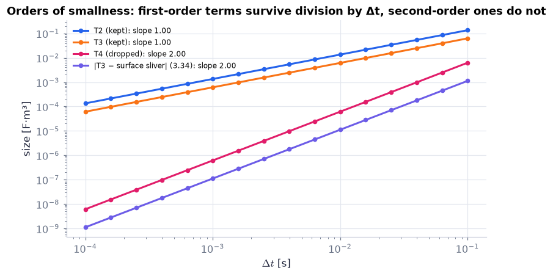

```python
T2 = np.array([rows[d]["T2"] for d in dts]); T3 = np.array([rows[d]["T3"] for d in dts])   # the kept terms [F·m³]
T4 = np.array([rows[d]["T4"] for d in dts]); sl = np.abs([rows[d]["sliver_error"] for d in dts])   # the dropped pieces
fig, ax = plt.subplots(figsize=(7, 4))                # log–log axes
for y, col, lab in ((T2, COLORS["blue"], "T2 (kept)"), (T3, COLORS["orange"], "T3 (kept)"),
                    (T4, COLORS["rose"], "T4 (dropped)"), (sl, COLORS["accent"], "|T3 − surface sliver| (3.34)")):
    ax.loglog(dts, y, "o-", color=col, ms=4, label=f"{lab}: slope {observed_order(dts, y):.2f}")   # slope by least squares
ax.set_xlabel(r"$\Delta t$ [s]"); ax.set_ylabel("size [F·m³]"); ax.legend(fontsize=8)            # axes with units
ax.set_title("Orders of smallness: first-order terms survive division by Δt, second-order ones do not")
savefig(fig, "ch03", "rtt_orders"); plt.show()        # save to outputs/ch03 and draw
```

**What you see.** Four straight lines on log–log axes: two of slope 1 (blue, orange), two of slope 2 (rose, purple).

**How to read it.** After dividing by Δt, the slope-1 terms tend to finite rates (the volume and surface terms), while the slope-2 terms — T4 and the error of replacing the sliver by a surface integral — tend to zero. That is exactly why (3.33), $\frac{d}{dt}\int_{V^*}F\,dV=\lim\frac{1}{\Delta t}\{\int_{V^*}\Delta t\,\partial F/\partial t\,dV+\int_{\Delta V}F\,dV\}$, keeps two terms and drops the rest.

**What would change if…** …the sphere grew ten times faster: T3 and T4 would both grow ×10 (both ∝ ΔV), but T4/T3 would still be ∝ Δt.

📝 **Note.** **Ex. 3.2 — a growing cone** `N54` — A right circular cone of fixed height h has base radius r(t) growing at ṙ. Directly, $V=\tfrac13\pi hr^2$ gives $dV/dt=\tfrac23\pi hr_o\dot r$. By (3.35) with F = 1 and the cone as V*, only the sloping side contributes: a side point at height z moves outward at $(z/h)\dot r\,\mathbf e_R$, the outward normal is $\mathbf n=\mathbf e_R\cos\theta-\mathbf e_z\sin\theta$ (θ = the cone's half-angle, $\tan\theta=r_o/h$ — a fourth θ in this chapter), and the slanted area element is $dA=z\tan\theta\,d\varphi\,dz/\cos\theta$. ⚠️ Two print slips taught corrected: the base's points move radially in its own plane, so it is **b·n = 0** there (not b = 0), which is all the theorem needs; the "[?]" in the printed integrand is just the factor z.

$$ \frac{dV}{dt}=\int_{z=0}^{h}\int_{\varphi=0}^{2\pi}\frac zh\dot r\,\mathbf e_R\cdot(\mathbf e_R\cos\theta-\mathbf e_z\sin\theta)\,z\tan\theta\,d\varphi\frac{dz}{\cos\theta}=\frac{2\pi\dot r\tan\theta}{h}\int_0^hz^2dz=\tfrac23\pi h^2\dot r\tan\theta=\tfrac23\pi hr_o\dot r $$

```python
print(ch03.example_3_2(1.0, 0.5, 0.1))               # h = 1 m, r_o = 0.5 m, ṙ = 0.1 m/s: dV/dt three ways [m³/s]
```

```
{'direct': 0.10471975511965977, 'rtt_dblquad': 0.1047197551196598, 'rtt_cv': 0.10471975511965975, 'rtt_closed_form': 0.10471975511965977}
```

**What does the code above do?**

The direct derivative, the book's surface integral by `dblquad` (P87), the general quadrature on `GrowingCone` and the closed form all give 0.10472 m³/s.

📝 **Note.** **Fig. 3.18, our 2-D drawing** `N55` — a deforming, translating ellipse over the ramp field F = 1 + 0.5x₁.

```
volume term 0.0000 + surface term 0.9425 = 0.9425;  measured d/dt of the integral 0.9425
```

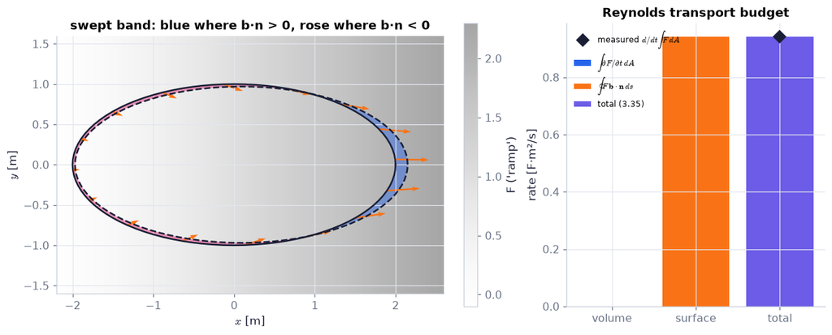

```python
from scripts.ch03_drawings import rtt_blob_figure             # drawing helper; the numbers come from ch03.rtt_ellipse_2d
fig, terms, fd = rtt_blob_figure(a=2.0, b=1.0, adot=0.2, bdot=-0.1, cdot=(0.3, 0.0), F_name="ramp", dt=0.3)   # ellipse 2 × 1 m
fig.axes[0].set_title("swept band: blue where b·n > 0, rose where b·n < 0")   # a shorter title that fits the panel
print(f"volume term {terms[0]:.4f} + surface term {terms[1]:.4f} = {terms[2]:.4f};  measured d/dt of the integral {fd:.4f}")   # [F·m²/s]
savefig(fig, "ch03", "fig3_18_rtt"); plt.show()               # save to outputs/ch03 and draw
```

**What you see.** Left: an ellipse (solid) and its position a moment later (dashed) over a grey ramp, orange b arrows on the boundary, blue slivers on the right where the boundary advances and rose slivers at the top and bottom where it retreats. Right: an orange surface bar and a purple total bar, both reaching the black diamond; the blue volume bar has zero height.

**How to read it.** The rose slivers are *negative* volume — the same formula counts them with the right sign. Here F does not depend on time, so the volume term is zero and the whole change comes from the moving surface; the sum of the bars is the measured rate.

**What would change if…** …b = 0 (a fixed box): the slivers and the orange bar would vanish, and d/dt could pass inside the integral.

#### 🎮 Interactive: What changes inside a moving box?

**Why interactive:** the theorem is a budget whose terms change sign with the direction the walls move; moving the walls yourself and watching the slivers turn blue or rose shows why one signed surface term covers all cases. A moving boundary sweeps a band whose colour shows the sign of b·n; bars for the volume and surface terms of $\frac{d}{dt}\int_{V^*}F\,dV=\int_{V^*}\frac{\partial F}{\partial t}dV+\int_{A^*}F\,\mathbf b\cdot\mathbf n\,dA$ *(Eq. 3.35)* add up to the measured rate of change of ∫F, and a Δt slider shows the dropped second-order term vanish. Modes: Leibniz in 1-D, a deforming ellipse in 2-D, and the growing cone of Ex. 3.2.

**What to try:**

- Preset 'fixed volume (b = 0)': the orange bar disappears.
- Preset 'rigid translation in a uniform F': the two terms cancel exactly — a uniform F carried along does not change.
- Make one side retreat: its sliver turns rose and subtracts.
- Derivation tab, D22: at the 'drop second order' step, scrub Δt on the log–log view.

```python
show_viz("ch03", "reynolds_transport_cv")   # full-width explainer; ⤢ Full screen for more room
```

🎮 Interactive 7/7 What changes inside a moving box? Open alone ↗

[interactive chart not shown]

**What would change if…** …F were the density ρ and V* a material volume (b = u)? The left side is the rate of change of the lump's mass, which is zero; D24's steps then give $\frac{D\rho}{Dt}+\rho\nabla\cdot\mathbf u=0$ — the continuity equation that opens Chapter 4. With F = ρu you get Newton's law for the lump; with F = ρ(e + u²/2), the energy equation.

*↪ S01 · Practise on the book's Exercises 3.1–3.30 (curvilinear operators, flow lines, the Galilean proof, strain and rotation of simple flows, circulation, transport-theorem checks). The derivations the text leaves to Exercises 3.3, 3.12, 3.17–3.20, 3.23, 3.26, 3.28 and 3.30 are written out above in our own words (D03, D06, D10, D11, D13, D17, N37, D20, D23, D24).*

*↪ S02 · Further reading: Van Dyke's *An Album of Fluid Motion* and Samimy et al.'s *A Gallery of Fluid Motion* for photographs of streak and path lines; Riley, Hobson & Bence for Leibniz's rule; Thompson (1972) for the geometric transport-theorem argument (all cited in the book's literature list).*

## ✅ What should have clicked

- **C01** A particle is a label; a field is a function of (x, t); $F[\mathbf r(t;\mathbf r_o,t_o),t]=F(\mathbf x,t)$ at $\mathbf x=\mathbf r$ *(3.2)* translates between them.
- **C02** $\frac{DF}{Dt}=\frac{\partial F}{\partial t}+\mathbf u\cdot\nabla F$ *(3.5)*: what a moving parcel feels = what a fixed probe sees + what it meets by moving.
- **C03** A streamline is tangent to $\mathbf u$ at one frozen instant: $dx/u=dy/v=dz/w$ *(3.7)*.
- **C04** A path line follows one particle, $d\mathbf r/dt=\mathbf u(\mathbf r,t)$ *(3.8)*; a streak line collects everything from one port; in unsteady flow the three lines differ.
- **C05** The acceleration $\frac{\partial\mathbf u}{\partial t}+(\mathbf u\cdot\nabla)\mathbf u$ is the same for every observer moving at constant velocity *(3.9)*; only its split is not.
- **C06** $du_i=(\partial u_i/\partial x_j)\,dx_j$ *(3.10)*: the neighbourhood of a point moves linearly.
- **C07** The diagonal of S is the stretching rate per length; along any direction $\mathbf n$ it is $\mathbf n\cdot\mathbf S\cdot\mathbf n$.
- **C08** The off-diagonal $S_{12}$ is half the closing rate of a right angle; rigid motion has S = 0.
- **C09** $\frac1{\delta V}\frac{D(\delta V)}{Dt}=\frac{\partial u_i}{\partial x_i}=S_{ii}$ *(3.14)*: divergence is the swelling rate.
- **C10** A fluid element spins at ½ω — the average of any perpendicular pair of threads — and the spin depends on the observer's rotation ($\omega'_z=\omega_z-2\Omega$).
- **C11** $du_i=S_{ij}dx_j+\tfrac12(\boldsymbol\omega\times d\mathbf x)_i$ *(3.19)*: deformation plus rigid rotation.
- **C12** S stretches a small sphere into an ellipsoid on its principal axes, $d\bar u_\alpha=\bar S_{\alpha\alpha}d\bar x_\alpha$ *(3.21)*, at the first instant.
- **C13** $\omega_z=\frac1r\frac{\partial}{\partial r}(ru_\theta)-\frac1r\frac{\partial u_r}{\partial\theta}$ *(3.23)*: solid-body rotation spins every element (2ω₀); the line vortex spins none (except its axis).
- **C14** Real vortices have a solid-body core and an irrotational outside; the peak wind is at σ (Rankine, $u_\theta=\Gamma r/2\pi\sigma^2$ inside, *(3.28)*) or 1.1209σ (Gaussian, $u_\theta=\frac{\Gamma}{2\pi r}(1-e^{-r^2/\sigma^2})$ *(3.29)*).
- **C15** $\frac{d}{dt}\int_{V^*}F\,dV=\int_{V^*}\frac{\partial F}{\partial t}dV+\int_{A^*}F\,\mathbf b\cdot\mathbf n\,dA$ *(3.35)*: change in place + what the moving walls sweep (signed).

**What later chapters build on**

- Ch. 4: the transport theorem *(3.35)* + $\frac{DF}{Dt}=\frac{\partial F}{\partial t}+\mathbf u\cdot\nabla F$ *(3.5)* → continuity, Cauchy's equation, energy; S → the Newtonian stress law; rotating frames ($\omega'=\omega-2\Omega$) → Coriolis.
- Ch. 5: vorticity, circulation $\Gamma=\oint\mathbf u\cdot d\mathbf s$ *(3.18)*, vortex stretching (S along ω), the Lamb–Oseen vortex.
- Ch. 6: irrotational flow $\boldsymbol\omega=0$ *(3.17)*, the point vortex $u_\theta=B/r$ *(3.25)*, the cylinder of Fig. 3.2.
- Ch. 7: particle orbits via $d\mathbf r/dt=\mathbf u(\mathbf r,t)$ *(3.8)*; wave frames via Galilean invariance, $\frac{\partial\mathbf u}{\partial t}+(\mathbf u\cdot\nabla)\mathbf u=\frac{\partial\mathbf u'}{\partial t'}+(\mathbf u'\cdot\nabla')\mathbf u'$ *(3.9)*.
- Ch. 13: absolute vs relative vorticity, frontogenesis on principal strain axes, cyclone profiles.

**Not taught here (and where to find it)**

- Curvilinear forms of ∇, ∇², (u·∇)u (Appendix B; used from Ch. 4 on).
- Solutions for the velocity potential (Ch. 6).
- Viscous spreading of the Gaussian vortex (Ch. 5, 8).

← All chapters

← PreviousNext →

Code and explanations: shammun/fluidpy (MIT). The book is not reproduced here; equations are cited by number.